# 公平与效率：同一个温度

初稿 · 探索性笔记：温度这个符号能走多远

最后更新：2026-10-29 20:12 EDT

*这是一份**初稿**：E4/E3/E5 三个新实验已经落地并接入正文；理论映射、文献核对与经验校准仍未完成。结论按目前证据陈述，未完成的部分明确标出。*

*本文反复用到最大熵、Lagrange 乘子、KL 散度、玻尔兹曼分布这几件工具，它们的完整推导在前一篇[《从熵到分布：指数、幂律、正态与玻尔兹曼的统一逻辑》](https://nyuhuyang.github.io/notes/exp_normal_boltzmann_zh.html)里。这里不重讲，但每次用到都就地给出对应章节的链接，方便随时回去复习。*

# 1 论点

公平与效率通常被摆成一根跷跷板：要这头就得让那头。本文想说的是，这根跷跷板中间的支点是**一个可以写出来的量**——

$$\boxed{\;T\;}\qquad\text{温度（=
Lagrange 乘子 }\lambda\text{ 的倒数）}$$

它一头连着熵（也就是不平等），一头连着约束（也就是产出）。在指数族模型里，$T$ 与熵-产出兑换率是同一个参数；它是否同时等于”你对谁行的无知程度”，取决于具体的信息模型，**不是恒等**。第 6 章会把这个边界写清，并给出一个不经过 $T$ 的共担机制。

> **公平不是效率的对立面，而是对不确定性的正确定价。** 把不确定性当成零——自以为准确识别了能力——才制造出虚假的公平-效率对立。

后面会给出一个可证伪的推论，并用模拟检验它：**在 $x\propto a^\beta$ 这条策略族内**，比某个临界集中度更集中的配置会同时损失产出和公平；这不是全局帕累托结论，只是这条参数化曲线上的支配关系。

# 2 公平这一侧：三根已经存在的线

## 2.1 熵就是不平等的度量

这不是比喻。经济学里的 **Theil 指数**，定义就是实际分布相对于完全平均分布的 KL 散度：

$$T_{\text{Theil}} \;=\; \sum_i p_i
\ln\frac{p_i}{1/N} \;=\; \ln N - H[p]$$

**不平等 = 最大可能的熵 − 实际的熵。** 广义熵族 GE($\alpha$)（含平均对数偏差、Theil、半平方变异系数）与 Atkinson 指数都属这一家。所以”公平”和”熵”不是分处两个空间、需要架桥的东西——**它们是同一个量的两种写法**，中间隔着一个减号。

（**复习**：[熵的定义](https://nyuhuyang.github.io/notes/exp_normal_boltzmann_zh.html#%E4%BF%A1%E6%81%AF%E7%86%B5%E7%9A%84%E5%AE%9A%E4%B9%89)、[KL 散度与它的两种取向](https://nyuhuyang.github.io/notes/exp_normal_boltzmann_zh.html#%E7%BB%86%E8%8A%82kl-%E6%95%A3%E5%BA%A6%E4%B8%8E%E4%B8%A4%E4%B8%AA%E9%80%89%E6%8B%A9)。Theil 指数就是那里的 $D_{\mathrm{KL}}(p\,\|\,\text{均匀})$，换了个经济学的名字。）

## 2.2 $\lambda$ 是公平与效率的兑换率

固定产出、最大化熵，是一个标准的约束优化：

$$\max_p\; \underbrace{H[p]}_{\text{公平}}
\quad\text{s.t.}\quad \underbrace{\langle E\rangle}_{\text{产出}} =
\text{const}
\qquad\Longrightarrow\qquad
\lambda \;=\; \frac{\partial H}{\partial \langle E\rangle} \;=\;
\frac{1}{T}$$

（**复习**：[Lagrange 乘子从零讲起](https://nyuhuyang.github.io/notes/exp_normal_boltzmann_zh.html#%E6%8B%89%E6%A0%BC%E6%9C%97%E6%97%A5%E4%B9%98%E5%AD%90%E9%9B%B6%E5%9F%BA%E7%A1%80%E7%89%88)（几何图像：约束面上梯度共线）、[乘子推导出分布的一般形式](https://nyuhuyang.github.io/notes/exp_normal_boltzmann_zh.html#%E6%8B%89%E6%A0%BC%E6%9C%97%E6%97%A5%E4%B9%98%E5%AD%90%E6%8E%A8%E5%AF%BC%E5%88%86%E5%B8%83%E7%9A%84%E4%B8%80%E8%88%AC%E5%BD%A2%E5%BC%8F)。而 $\lambda = \partial H/\partial\langle E\rangle = 1/T$ 这一步，正是[温度的定义 $1/T = \partial S/\partial E$](https://nyuhuyang.github.io/notes/exp_normal_boltzmann_zh.html#%E6%B8%A9%E5%BA%A6%E6%98%AF%E4%BB%80%E4%B9%881t-partial-s-partial-e)——本文全篇的”温度”就是它，一个字都没改。）

乘子从来都是影子价格：**每多要一单位产出，要付出多少公平**。换成物理学家的写法就是自由能

$$F \;=\; \underbrace{\langle
E\rangle}_{\text{效率}} \;-\;
T\cdot\underbrace{S}_{\text{公平}}$$

把 $F$ **最小化**：$T\to 0$ 只认产出，赢家通吃；$T\to\infty$ 只认熵，配置趋于均匀——均分仍有平均产出，**不是 0**。产出归零是另一个约束的极限，不是这里的均分。中间那条曲线就是公平-效率前沿，而**它的斜率是 $T$**（符号随 $E$ 的定义；若把 $F$ 当最大化目标，符号要反过来）。

$T\to0$ 那一端比”很不平等”更糟，而且糟法是可以算出来的：财富分布的幂律尾指数一旦跌到 $\alpha\le 1$，**分布的均值就不再存在**——不是”均值很大”，是那个积分发散。于是”人均产出”这个概念本身失效，所有搭在均值上的语言（人均 GDP、平均工资、税基）跟着一起失效，在有限人口里它表现为财富凝聚：单独一个人占据宏观份额。姊妹篇《再论不平等的起源》把这个崩塌点算成了一张表。**零温不是效率的极限，是描述能力的终点。**

## 2.3 理性人是零温极限

经济学的理性人假设，在行为经济学里早就有了带温度的版本。**量子响应均衡（QRE）**下，agent 选行动 $i$ 的概率是

$$P(i) \;\propto\; e^{\beta
u_i}$$

这就是[玻尔兹曼分布](https://nyuhuyang.github.io/notes/exp_normal_boltzmann_zh.html#boltzmann-%E5%8E%9F%E7%90%86%E5%B0%B1%E6%98%AF%E6%9C%80%E5%A4%A7%E7%86%B5%E5%8E%9F%E7%90%86)（**复习**：玻尔兹曼原理就是最大熵原理，$P\propto e^{-\beta E}$ 是”固定平均能量下熵最大”的解），$\beta$ 是理性程度、也是逆温度。$\beta\to\infty$ 时永远选效用最大的那个（完全理性），$\beta\to0$ 时纯随机。**完全理性不是常态，是温度为零的极限。** Sims 的**理性疏忽**给出了容量约束的一般框架 (Sims 2003)；离散选择里把 logit 形式显式推出来的，通常归 Matějka–McKay (Matějka and McKay 2015)。在这个具体模型里，信息成本扮演温度——偏离理性不是”非理性”，是为信息付的熵税。

进化那一侧不是自动的同一件事。**复制者动力学加上变异，并不自动给出玻尔兹曼分布**：两类型、适应度差 1、对称变异 $m$ 的驻点满足 $p(1-p)+m(1-2p)=0$；$m=1$ 时 $p=(\sqrt5-1)/2$，而 Gibbs 在 $T=m$ 时给 $p=e/(1+e)$，两者不等。只有特定的适应度-变异核才让 Gibbs 成立；**在那个核里**变异率扮演温度。纯选择（零变异）会收敛到单一基因型：短期适应度最高、多样性为零、极脆；选择加变异才维持多样性。

而人类身上有一台**现成的高温装置**。在动物界，等级制才是常态——狒狒、黑猩猩、狼群都有稳定的支配序列。人类的狩猎采集社会却异常平等：食物强制分享、没有世袭首领、对想独占或逞威的人主动压制。Boehm 把这套机制叫做**反向支配等级**——多数人结成联盟，把任何试图爬上去的个体按回去 (Boehm 1999)。

用本文的语言读这件事：**压制独占等于往系统里强行注入变异，也就是把温度顶住不让它掉到零。** 于是”人类为什么这么平等”有了一个不诉诸道德的答案——在一个没人知道谁行、而且明天会不会打到猎物都不确定的世界里，**维持高温本身就是效率最优**。这也顺带说明了为什么平等需要**机制**去维持：不平等是默认值（姊妹篇《再论不平等的起源》证明了连绝对公平的规则都会自动产出 Gini 0.5），而平等是一项要花力气的成就。

# 3 公平的基线：程序完全公平会产出什么

这一节只取一个结论。完整的模拟、推导和后果放在姊妹篇《再论不平等的起源》里。

设定是一台**零和**的经济钉板（动能交换模型 (Drăgulescu and Yakovenko 2000)，综述见 (Yakovenko and Rosser 2009)）：$N$ 个人各持 1 单位资源，随机配对，把两人手里的钱**按随机比例重新分配**，总量守恒。没有能力差异，没有利息，没有人被偏袒，规则对所有人一字不差——**程序意义上完全公平**。

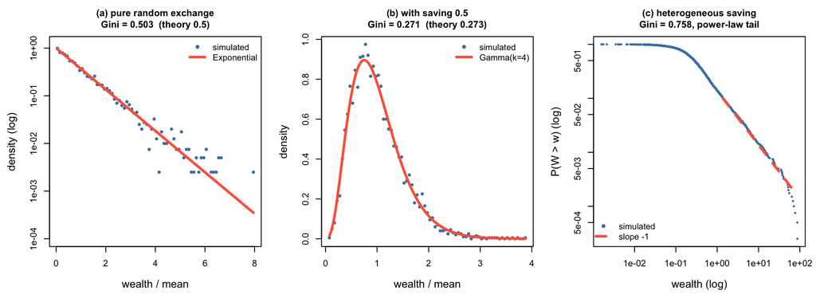

```r
set.seed(1)
kinetic <- function(N = 4000, rounds = 1200, lam = 0, lam_vec = NULL){
  w <- rep(1, N); L <- if (is.null(lam_vec)) rep(lam, N) else lam_vec; half <- N/2
  for (r in 1:rounds){
    idx <- sample.int(N); i <- idx[1:half]; j <- idx[(half+1):N]
    pooled <- (1-L[i])*w[i] + (1-L[j])*w[j]; e <- runif(half)
    w[i] <- L[i]*w[i] + e*pooled
    w[j] <- L[j]*w[j] + (1-e)*pooled
  }
  w
}
wa <- kinetic(lam = 0)          # (a) 纯随机交换
wb <- kinetic(lam = 0.5)        # (b) 每人留存一半再交换
set.seed(2)
wc <- kinetic(lam_vec = runif(4000))   # (c) 储蓄倾向因人而异

par(mfrow = c(1, 3), mar = c(4.4, 4.6, 3.4, 1))
u <- wa/mean(wa); h <- hist(u[u < 8], breaks = 60, plot = FALSE)
plot(h$mids, h$density, log = "y", pch = 16, col = "steelblue", cex = 0.8, ylim = c(1e-4, 1.2),
     main = sprintf("(a) pure random exchange\nGini = %.3f  (theory 0.5)", gini(wa)),
     xlab = "wealth / mean", ylab = "density (log)", cex.lab = 1.2, cex.main = 1.05)
curve(exp(-x), add = TRUE, col = "tomato", lwd = 3)
legend("topright", c("simulated", "Exponential"), pch = c(16, NA), lwd = c(NA, 3),
       col = c("steelblue", "tomato"), bty = "n", cex = 0.95)

ub <- wb/mean(wb); hb <- hist(ub, breaks = 60, plot = FALSE)
plot(hb$mids, hb$density, pch = 16, col = "steelblue", cex = 0.8,
     main = sprintf("(b) with saving 0.5\nGini = %.3f  (theory 0.273)", gini(wb)),
     xlab = "wealth / mean", ylab = "density", cex.lab = 1.2, cex.main = 1.05)
curve(dgamma(x*4, shape = 4)*4, add = TRUE, col = "tomato", lwd = 3)
legend("topright", c("simulated", "Gamma(k=4)"), pch = c(16, NA), lwd = c(NA, 3),
       col = c("steelblue", "tomato"), bty = "n", cex = 0.95)

sc <- sort(wc, TRUE); sf <- seq_along(sc)/length(sc)
plot(sc, sf, log = "xy", pch = 16, col = "steelblue", cex = 0.55,
     main = sprintf("(c) heterogeneous saving\nGini = %.3f, power-law tail", gini(wc)),
     xlab = "wealth (log)", ylab = "P(W > w) (log)", cex.lab = 1.2, cex.main = 1.05)
xx <- 10^seq(log10(quantile(wc, .9)), log10(max(wc)), length.out = 40)
lines(xx, 0.1*(xx/quantile(wc, .9))^(-1), col = "tomato", lwd = 3, lty = 2)
legend("bottomleft", c("simulated", "slope -1"), pch = c(16, NA), lwd = c(NA, 3),
       lty = c(NA, 2), col = c("steelblue", "tomato"), bty = "n", cex = 0.95)
```

左图是纯随机交换的平衡态：**指数分布**，在半对数坐标上一条直线，Gini 0.503。这不是巧合——守恒量的无偏随机再分配，平衡态就是固定均值下的最大熵分布（**复习**：[指数分布 = 非负 + 固定均值下的最大熵](https://nyuhuyang.github.io/notes/exp_normal_boltzmann_zh.html#%E6%8C%87%E6%95%B0%E5%88%86%E5%B8%83-%E6%9C%80%E5%A4%A7%E7%86%B5-%E9%9D%9E%E8%B4%9F-%E5%9D%87%E5%80%BC%E7%BA%A6%E6%9D%9F)）。而**指数分布的 Gini 恰好等于 $1/2$，与均值无关**。也就是说：

> **程序完全公平（无人被偏袒），结果的 Gini 也是 0.5。**

这是一条**热力学不平等基线**。它把”公平”这个词劈成两半：过程的公平不蕴含结果的平等，最大熵态自带相当程度的不平等。

中图和右图是两个改动。**每人先留存一半再交换**，分布变成 Gamma，Gini 掉到 0.271——储蓄这个看似与公平无关的习惯，本身就是均等化力量 (Chakraborti and Chakrabarti 2000)。**储蓄倾向因人而异**（有人存得多有人存得少，这是唯一的异质性），尾巴立刻变成幂律，Gini 冲到 0.758 (Chatterjee et al. 2004)。右图的不平等不是因为谁”能力强”，纯粹是因为**规则对不同人不一样**——异质性一进入乘性结构，指数尾就变成幂律尾（**复习**：[scale-free：乘性无记忆性](https://nyuhuyang.github.io/notes/exp_normal_boltzmann_zh.html#scale-free%E6%8A%8A%E4%B9%98%E6%80%A7%E6%97%A0%E8%AE%B0%E5%BF%86%E7%94%BB%E5%87%BA%E6%9D%A5%E5%B9%B6%E8%AF%81%E6%98%8E%E5%AE%83%E5%94%AF%E4%B8%80)）。

姊妹篇里还有三件本节不展开的事：$1/2$ 的闭式推导（以及它为什么本质上是**数微观态**的结果，跟竞争无关）；0.5 的具体社会后果（只有 $1/e=36.8\%$ 的人在平均线以上，而这少数人拿走 $2/e=73.6\%$）；以及把”零和”这个前提拆掉之后会怎样——**蛋糕做大本身不改变 Gini，改变它的是增量按什么规则分**，按人头分把它压到 $1/3$，按财富比例但回报随机则把它顶到 0.8 以上。

对本文只需要留下这条基线，和它的一句读法：**最大熵态自带的不平等，是”没有人被特殊对待”的价格，不是任何人的过错。** 下一节转到效率那一侧——那里的问题正是”增量该配给谁”。

# 4 效率这一侧：能力差异怎么进来

上面的模型里所有人一模一样。现实显然不是——人在不同维度上的能力差别巨大，“把资源配给能干的人”看起来是效率的常识。这一侧要小心地展开。

## 4.1 先把”效率”定死：帕累托最优是一条线，不是一个点

在用”效率”这个词论证任何事情之前，先把它的经典定义和推导过一遍。这段是教科书内容，但**恰恰是被跳过的那一步埋着本文要拆的东西**。

**定义。** 配置 $x$ 是**帕累托最优**的，如果不存在另一个可行配置 $x'$，使得所有人都不更差、且至少一人更好。

注意这个定义的形状：它是一个**否定式的筛子**，只排除掉”还有免费午餐”的配置。它没说该选哪个。

**第一层：纯分配问题里，这个筛子几乎什么都筛不掉。**

固定资源 $R$，每个人的效用只随自己拿到的份额单调递增。取任意一个把资源分完的方案 $\sum_i x_i = R$。想让某人变好，必须给他更多，就必须从别人那里拿——那个人就变差了。所以：

> **任何把资源分完的方案都是帕累托最优的**，包括”全给一个人、其余人拿零”。

这不是诡辩，是定义的直接推论。**帕累托最优对不平等完全沉默。** 凡是拿”这样有效率”来论证集中的说法，只要它的效率概念是帕累托的，那句话就是空的——一人独占和完全平均在这把尺子下并列。

**第二层：加进生产，筛子才有内容，但只筛掉”浪费”。**

产出依赖配置时（本文取 $\sum_i a_i x_i^\gamma$），帕累托最优多了一个必要条件，而且可以构造性地证出来。

反证：设内点配置 $x$ 处两人的边际回报不等，

$$\frac{\partial}{\partial x_i}\Big(a_i
x_i^{\gamma}\Big) \;>\; \frac{\partial}{\partial x_j}\Big(a_j
x_j^{\gamma}\Big)$$

把 $\varepsilon$ 从 $j$ 挪到 $i$。一阶下总产出**严格增加**，增量为 $\varepsilon\,(\partial_i - \partial_j) > 0$。把这份增量的一部分补偿给 $j$，$j$ 不更差，$i$ 更好——找到了帕累托改进，所以原配置不是帕累托最优。∎

结论就是那条经典的**边际条件**：内点帕累托最优要求所有人的边际回报相等（教科书里的 MRS 相等 / 边际产出相等）。它排除的只有一件事：**浪费**。产出怎么分，它一个字都没说。

**第三层：帕累托最优 ⟺ 某组权重下的加权和最大。**

这是把”一整条前沿”和”一个具体的优化问题”接起来的那一步（Negishi）。凸情形下：

$$x \ \text{帕累托最优}
\qquad\Longleftrightarrow\qquad
\exists\, w_i \ge 0,\ \ x \in \arg\max \sum_i w_i\,u_i(x)$$

几何上就是**支撑超平面定理**：可达效用集是凸的，前沿上每一点都有一个支撑超平面，那个超平面的法向就是权重 $w$。权重比 $w_i/w_j$ 是这一点上的**兑换率**。在指数族模型里，$\lambda$ 与 $T$ 互为倒数；但**福利权重比是另一个对象**，不能无条件等同于 $T$——它取决于你给谁加权，而不是模型的不确定性。

**落点。这一整套推导的净结果是三句话：**

1. **效率给方向，不给点。** 帕累托最优是一整张前沿面。要从前沿上挑一点，必须外生地填进权重 $w_i$。
2. **下一节那个”最优配置”是权重相等的那一点。** $\max \sum_i a_i x_i^\gamma$ 默认了 $w_i \equiv 1$——**这已经是一个伦理选择，不是效率结论**。带权重的版本只差一步：$x_i \propto (w_i a_i)^{1/(1-\gamma)}$。
3. **本文其实是在另一张纸上做同一件事。** 自由能 $F = \langle E\rangle - T\,S$ 是在 (产出, 公平) 这个二维目标空间里的标量化；在固定均值、**最小化** $F$ 的约定下，$T$ 是前沿的斜率（符号随 $E$ 的定义）。而第 5 节要报的那个结论——过了某个临界集中度，产出与公平**同时**下降——用这套语言说只是：**在 $x\propto a^\beta$ 这条策略族内被支配**，不是全局帕累托前沿。它们不是全局意义上的浪费，只是这条曲线上的浪费。

（顺带一提福利定理的位置：第一福利定理说竞争均衡是帕累托最优的，第二福利定理说任何帕累托最优点都可以通过重新分配初始禀赋、再让市场跑一遍来实现。第二条常被读成”效率与分配可以分离”——在理论上确实如此，代价是那个”重新分配禀赋”的动作本身没有价格。）

## 4.2 先拆一个藏在句子里的假设

“能力高的人配更多资源”默认了**能力是一维的**——有”高低”才能排序。而一旦承认能力是多维的，两个后果立刻出现：

- **赢家通吃是降维的产物。** 多维下”最强者”通常不存在，最优解是**匹配**（指派问题 / 最优传输），不是排序。
- **比较优势**：一个人哪怕**样样绝对不如别人**，把资源分给他仍可能提高总产出——这是 Ricardo 两百年前就讲清楚的事。绝对最强者拿走一切，在多维下几乎总是次优。

所以”效率要求集中”这个直觉，有相当一部分是把能力压成标量时产生的幻觉。（多维匹配的模拟见 §4.6。）

## 4.3 若真的知道能力：最优配置是能力的幂函数

先退回一维，并且假设你**准确知道**每个人的能力 $a_i$。产出取边际递减的形式 $\sum_i a_i x_i^{\gamma}$（$\gamma<1$），资源总量 $\sum_i x_i = R$。一行 Lagrange：

$$\gamma a_i x_i^{\gamma-1} = \lambda
\qquad\Longrightarrow\qquad
\boxed{\;x_i \;\propto\; a_i^{\,1/(1-\gamma)}\;}$$

**效率最优配置是能力的幂函数**，幂指数 $1/(1-\gamma)$ 完全由边际递减的程度决定：

- $\gamma \to 1$（收益不递减）→ 指数 $\to\infty$ → **赢家通吃**（角点解，配置的熵为零）
- $\gamma = 0.5$ → $x_i \propto a_i^2$ → 资源分布比能力分布**更悬殊**
- 递减越强 → 越接近按能力比例分配

顺带一提：这里冒出来的又是幂律，但它**不是反馈生成的，是优化生成的**。

还能把”效率要求多少不平等”变成一个能报数的量：若能力服从对数正态 $\sigma_a$，则资源服从对数正态 $\sigma_x = \sigma_a/(1-\gamma)$——**配置规则把能力的不平等放大了 $1/(1-\gamma)$ 倍**，对应 Gini $=2\Phi(\sigma_x/\sqrt2)-1$。

## 4.4 但你不知道能力——于是熵以效率的名义回来

上面整套推导有一个要命的前提：**你知道 $a_i$**。现实里能力是带噪声测量的、多维的、而且往往只在匹配对了之后才显形。

一旦承认这点，分散配置就不再只是”为公平付的税”；它可能本身变成效率最优。但要把三条理由分开，不能混成一个 $T$：

1. **探索与利用。** 不知道谁行，全押当前看起来最好的人，就永远学不到新信息。最优策略族是 softmax：$x_i \propto e^{\beta \hat a_i}$——玻尔兹曼形式，$\beta$ 是你对自己估计的信心。
2. **鲁棒性对偶。** “最大化产出 $+\,T\times$熵”是一个 **KL 罚问题**；它的对偶是
   $$\sup_Q\{E_Q[u]-T\,D_{\mathrm{KL}}(Q\|P)\}=T\log
   E_P[e^{u/T}].$$
   $T$ 是 KL 的罚系数。若改成 KL **半径**约束 $D_{\mathrm{KL}}\le\eta$，乘子与 $\eta$ 是约束关系，**不是 $T=\eta$**；把 $T$ 直接叫”不确定性集合的半径”是错的。
3. **Kelly 与遍历性。** 增长是乘性的时候，最大化期望收益是错的目标（会破产），正确目标是期望对数；Kelly 最优是按概率比例下注 $x=p$。这是**非遍历性**，不需要不确定性，也不经过 $T$；它单独构成第 6.1 节那根柱子。

前两条汇到指数族：

$$\max_x\; \sum_i a_i x_i \;+\; T\,H[x]
\qquad\Longrightarrow\qquad
\boxed{\;x_i \;\propto\; e^{\,a_i/T}\;}$$

在这个模型里 $T\to0$ 赢家通吃，$T$ 大平均分。**Kelly 的最优是 $x=p$，不是 $e^{a/T}$**；不要把它塞进同一个式子。E5 的财富池连 $T$ 都不经过。

## 4.5 互补性：效率要求的符号会翻转

第 4.3 节的 $x_i\propto a_i^{1/(1-\gamma)}$ 假设产出是加性的、边际递减；它没有回答另一件事：**能力之间能不能互相替代**。CES 把这个问题单独拎出来：

$$F(x)=\left(\frac1N\sum_{i=1}^N (a_i
x_i)^\rho\right)^{1/\rho},\qquad \sum_i x_i=R.$$

$\rho=0$ 是 Cobb–Douglas 极限 $F_0(x)=\exp\!\left(\frac1N\sum_i\log(a_i x_i)\right)$；$\rho<0$ 是互补（缺了谁都不行），$\rho>0$ 是替代。约束下的一阶条件给出

$$a_i^\rho x_i^{\rho-1}=c
\;\Longrightarrow\;
x_i\propto a_i^{\rho/(1-\rho)},\qquad
\beta^\ast(\rho)=\frac{\rho}{1-\rho}.$$

**四个必须先手算的点。** $\rho=0$：$\beta^\ast=0$，效率要求**正好等分**；$\rho=-1$：$\beta^\ast=-1/2$，资源向弱者倾斜；$\rho\to-\infty$（Leontief）：$F\to\min_i(a_i x_i)$，$x_i\propto 1/a_i$，与 $\beta^\ast\to-1$ 对上；$\rho\to1^-$：$\beta^\ast\to+\infty$，赢家通吃。

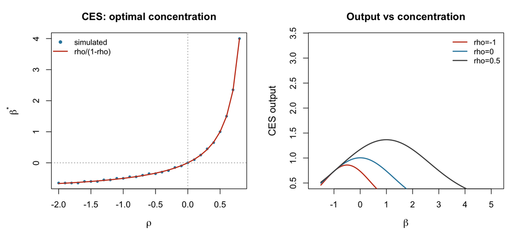

CES：符号翻转不等于平等化

| rho | beta*（模拟） | beta*（解析） | 最优点 F | beta=0 的 F | 最优点 Gini | 与能力的秩相关 |
| --- | --- | --- | --- | --- | --- | --- |
| -1.0 | -0.50 | -0.500 | 0.860 | 0.735 | 0.219 | -1.00 |
| 0.0 | 0.00 | 0.000 | 1.005 | 1.005 | 0.000 | — |
| 0.5 | 1.00 | 1.000 | 1.367 | 1.172 | 0.420 | +1.00 |
| 0.8 | 4.00 | 4.000 | 3.324 | 1.285 | 0.970 | +1.00 |

表里要同时看三件事：$\beta^\ast$ 在 $\rho=0$ 处正好是 0.00；$\rho<0$ 时为负（资源向弱者倾斜），但最优点 Gini 仍是 0.219（$\rho=-1$）——**方向反转不是平等化**；$\rho=0.8$ 时 $\beta^\ast=$ 4.00，Gini 到 0.970。Leontief 极限的独立核验（$N=8$、softmax、100 次重启）给出分配最大差 9.4e-05、最小产出绝对 gap 4.2e-05；这是**近似** optimizer。原始-对偶证书的最大违反量是 1.8e-15（应为 0）：$x_i\propto1/a_i$、$y_i\propto1/a_i$、$z=1/\sum(1/a)$ 同时可行且 primal=dual。

**这不是把第 5 章的核心实验再做一遍。** 第 5 章的产出是 $\sum a_i x_i^\gamma$（加性、边际递减），这里的 CES 是另一根轴：**可替代性**。CES 的 $\rho$ 和正文的 $\gamma$ 不能互相代入；把两者混谈会得到错误的“最优温度”。

## 4.6 多维匹配：标量化的损失

第 4.2 节说多维能力没有全序，效率最优是**匹配**而不是排序。这一节把“把多维压成一维”的代价量出来。

**设定。** $N=400$ 个 agent、$N$ 个任务；$a_i\in\mathbb{R}^d$，$w_j\in\mathbb{R}^d$，$y_{ij}=a_i\cdot w_j$。主设计是**独立、同尺度**的对数正态维度（$\rho_a=\rho_w=0$）；另跑完全相关（$\rho_a=\rho_w=1$）作为零损失对照。每个 $d\in\{1,2,3,5\}$ 做 $R=10$ 个独立世界。

**两条标量化基线。** A：等权 $s_i=\sum_k a_{ik}$、$t_j=\sum_k w_{jk}$，按秩 top-to-top 配对。B：分别对 $a$、$w$ 做中心化 PCA，取 PC1；**PC1 的符号必须 orient**（loadings sum 为正，或与 $s$、$t$ 正相关），否则 top-to-top 会静默变成 top-to-bottom。这里**不标准化**：各维同尺度、同方差；标准化会抹掉维度方差差异，反而改变要比较的问题。

**参考。** 用自写的零依赖 Hungarian 解无熵正则 assignment，作为精确匹配；随机匹配的期望产出是 $N\cdot\mathrm{mean}(Y)$。损失用两个口径：

$$L_{\text{surplus}}=\frac{\text{exact}-\text{scalar}}{\text{exact}-\text{random}},
\qquad
L_{\text{abs}}=\frac{\text{exact}-\text{scalar}}{N}.$$

$L_{\text{surplus}}$ 是匹配剩余的相对损失，不会被 $N d E[a]E[w]$ 这块常数项稀释；主假设只对它预先登记。$L_{\text{abs}}$ 是人均绝对损失。

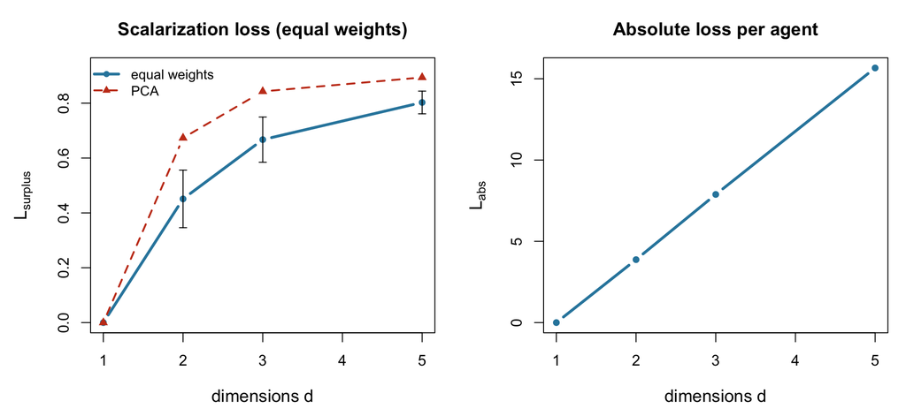

多维匹配：标量化损失随 d 上升

| d | L_surplus（等权） | 95% CI | L_abs | L_surplus（PCA） | PC1 特征值 gap |
| --- | --- | --- | --- | --- | --- |
| 1 | 0.000 | [-0.000, 0.000] | 0.000 | 0.000 | — |
| 2 | 0.451 | [0.346, 0.556] | 3.873 | 0.673 | 0.30 |
| 3 | 0.667 | [0.585, 0.750] | 7.884 | 0.843 | 0.20 |
| 5 | 0.803 | [0.761, 0.844] | 15.664 | 0.894 | 0.25 |

`d=1` 与完全相关维度的 $L_{\text{surplus}}$ 是 0.000 与 -0.000，零损失对照通过。独立维度下从 0.451（$d=2$）升到 0.803（$d=5$），人均绝对损失 15.664。最弱 agent 在精确匹配下拿到 0.929，等权标量化下只有 0.600。

**这不是复现 Ricardo。** 这里没有比较优势的生产模型，只有“把多维压成一维”这个动作本身；结论也只在本节的分布与 $d$ 网格内成立，不是普适常数。PCA 在独立等方差维度下本来就会退化成随机方向——表里的特征值 gap 就是提醒；主假设预先登记在**等权 baseline A**，PCA 只作对照。

# 5 核心实验：不确定性把最优集中度推低多少

理论说了两件可以检验的事。用模拟同时验它们。

**设定**：$N=2000$ 人，真实能力 $a_i\sim$ 对数正态$(0,\,0.8)$；你只观测到带噪声的估计 $\hat a_i = a_i\cdot e^{\varepsilon}$，$\varepsilon\sim N(0,\sigma_\varepsilon^2)$；按

$$x_i \;\propto\; \hat
a_i^{\,\beta}$$

分配资源（$\beta=0$ 是平均分，$\beta$ 越大越集中，$\beta\to\infty$ 是赢家通吃）；实际产出 $\sum_i a_i x_i^{\gamma}$，取 $\gamma=0.5$。

两个预测：

- **自校验**：无噪声时，最优集中度应当**正好等于** $1/(1-\gamma)=2$。
- **主预测**：噪声越大，最优集中度 $\beta^\ast$ 越低。

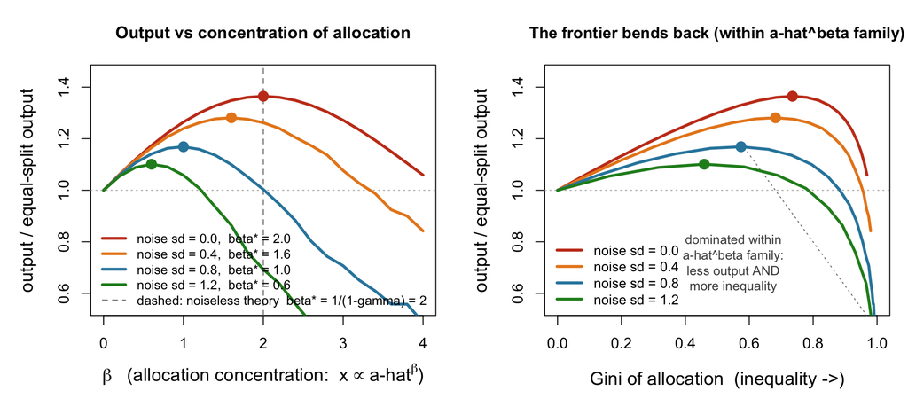

```r
set.seed(3)
N <- 2000; R_tot <- N; sig_a <- 0.8; gam <- 0.5
a <- rlnorm(N, 0, sig_a)

sweep_beta <- function(sig_e, betas, nrep = 100){
  t(vapply(betas, function(b){
    o <- g <- numeric(nrep)
    for (k in 1:nrep){
      ah <- a*exp(rnorm(N, 0, sig_e))
      x  <- R_tot * ah^b / sum(ah^b)
      o[k] <- sum(a * x^gam); g[k] <- gini(x)
    }
    c(out = mean(o), gini = mean(g))
  }, numeric(2)))
}
betas <- seq(0, 4, by = 0.2)
sigs  <- c(0, 0.4, 0.8, 1.2); cols <- c("#C73E1D", "#E8871E", "#2E86AB", "forestgreen")
res   <- lapply(sigs, sweep_beta, betas = betas)
base  <- res[[1]][1, "out"]                       # 等分配置的产出 = 1
bstar <- sapply(res, function(r) betas[which.max(r[, "out"])])
## E2 的两个端点和两个 Gini 从同一次模拟里取出，供正文内联；不再手写 +36%/+10%/0.735/0.459。
e2_gain_hi <- 100*(max(res[[1]][,"out"])/base - 1)
e2_gain_lo <- 100*(max(res[[length(res)]][,"out"])/base - 1)
e2_gini_hi <- res[[1]][which(betas == bstar[1]), "gini"]
e2_gini_lo <- res[[length(res)]][which(betas == bstar[length(bstar)]), "gini"]
freg("e2_gain_hi", e2_gain_hi, "sim", "ability_sweep", "noise-free peak output gain over equal split (%)")
freg("e2_gain_lo", e2_gain_lo, "sim", "ability_sweep", "highest-noise peak output gain over equal split (%)")
freg("e2_gini_hi", e2_gini_hi, "sim", "ability_sweep", "Gini at the noiseless optimum")
freg("e2_gini_lo", e2_gini_lo, "sim", "ability_sweep", "Gini at the highest-noise optimum")

par(mfrow = c(1, 2), mar = c(4.6, 5.0, 3.6, 1))
plot(NA, xlim = range(betas), ylim = c(0.55, 1.45),
     main = "Output vs concentration of allocation",
     xlab = expression(beta~"  (allocation concentration:  x"%prop%"a-hat"^beta*")"),
     ylab = "output / equal-split output", cex.lab = 1.2, cex.main = 1.1)
abline(h = 1, col = "gray70", lty = 3); abline(v = 2, col = "gray45", lty = 2)
for (i in seq_along(sigs)){
  y <- res[[i]][, "out"]/base
  lines(betas, y, col = cols[i], lwd = 3)
  points(bstar[i], max(y), pch = 16, col = cols[i], cex = 1.6)
}
legend("bottomleft",
       c(sprintf("noise sd = %.1f,  beta* = %.1f", sigs, bstar),
         "dashed: noiseless theory  beta* = 1/(1-gamma) = 2"),
       col = c(cols, "gray45"), lwd = c(3,3,3,3,1), lty = c(1,1,1,1,2),
       bty = "n", cex = 0.85)

plot(NA, xlim = c(0, 1), ylim = c(0.55, 1.45),
     main = "The frontier bends back (within a-hat^beta family)",
     xlab = "Gini of allocation  (inequality ->)",
     ylab = "output / equal-split output", cex.lab = 1.2, cex.main = 1.05)
abline(h = 1, col = "gray70", lty = 3)
for (i in seq_along(sigs)){
  y <- res[[i]][, "out"]/base; g <- res[[i]][, "gini"]
  lines(g, y, col = cols[i], lwd = 3)
  k <- which.max(y); points(g[k], y[k], pch = 16, col = cols[i], cex = 1.6)
  if (i == 3){
    arrows(g[k]+0.02, y[k]-0.02, g[length(g)]-0.02, y[length(y)]+0.02,
           code = 0, col = "gray50", lty = 3)
    text(0.55, 0.72, "dominated within\na-hat^beta family:\nless output AND\nmore inequality",
         col = "gray30", cex = 0.85)
  }
}
legend("bottomleft", sprintf("noise sd = %.1f", sigs), col = cols, lwd = 3, bty = "n", cex = 0.9)
```

**自校验通过**：无噪声时模拟给出 $\beta^\ast=$ 2.0，与理论值 $1/(1-\gamma)=2$ 一致（左图灰色虚线）。这说明模拟本身可信。

**主预测成立**：噪声一加，最优集中度单调下滑——

| 能力估计噪声 sd | 最优集中度 beta* | 峰值产出（等分=1） | 该点的 Gini |
| --- | --- | --- | --- |
| 0.0 | 2.0 | 1.365 | 0.735 |
| 0.4 | 1.6 | 1.281 | 0.682 |
| 0.8 | 1.0 | 1.169 | 0.574 |
| 1.2 | 0.6 | 1.101 | 0.459 |

三件事一起发生：**最优集中度降**、**集中能带来的产出增益缩水**（从 +36% 缩到 +10%）、**效率最优点自身的 Gini 变小**（0.735 → 0.459）。换句话说：

> **你越不了解谁行，效率最优的配置就越平等。** 公平不是从效率那里抢来的，它是无知的正确定价。

右图是这件事最直观的样子。横轴不平等、纵轴产出，每条曲线是 $\beta$ 从 0 走到 4 画出来的轨迹。**曲线会拐回来**：越过 $\beta^\ast$ 之后，继续集中资源**同时**损失产出、加剧不平等。那一段根本不在权衡曲线上——它不是”用公平换效率”，是两样都在扔。

这就是本文开头承诺的可证伪推论，现在它有了数值支持：

> **在这条 $x\propto\hat a^\beta$ 策略族内，任何比 $\beta^\ast$ 更集中的配置都是被支配的**（不是全局帕累托断言）。而 $\beta^\ast$ 随你对能力的不确定性下降。真实世界的能力估计噪声不小，于是”过度集中”的区域比直觉中大得多。

一个诚实的限定：**产出对 $\beta$ 的非单调性，边际收益递减（$\gamma<1$）本身就足以保证**——即使完全无噪声，$\beta$ 超过 2 之后产出照样掉。噪声的作用不是制造这个峰，而是**把峰往左推**。这两件事要分开说，不能混为一谈。

# 6 合起来：一个符号的边界

$$x_i \;\propto\; e^{\,a_i/T}$$

- 公平那一侧，$T$ 是熵-能量曲线的斜率，是公平与效率的兑换率；
- 效率这一侧，$T$ 是你不知道谁行的程度——**在特定的 logit/容量模型里**。

**在指数族模型里，前两重是同一个参数；第三重只在特定信息模型里对齐，不是恒等。** 这就是那根把两者连起来的线，也是它的边界。E5 的共担甚至不经过 $T$。

把三个对象当成同一个量，会把”参数化”误当成”证明”：无噪声 logit（$\beta=2$）对应 $T=1/2$，不是 $T=0$；有噪声时 $\sigma_\varepsilon$ 只通过具体模型的似然映射到 $T$，映射依赖先验与测量误差，不能反推。**同一个符号，不等于同一个已证参数。**

顺带值得记一笔：指数形式在这篇里出现了三次，在三个完全不同的层级上，形式相同，但理由不都是同一个：

| 层级 | 对象 | 形式 |
| --- | --- | --- |
| 宏观分布 | 随机交换下的财富 | $p(w)\propto e^{-w/\langle w\rangle}$ |
| 个体决策 | 有限理性 agent 的选择 | $P(i)\propto e^{\beta u_i}$ |
| 资源配置 | 不确定性下的最优分配 | $x_i\propto e^{a_i/T}$ |

## 6.1 共担：非遍历性作为第三根柱子

前两节的不确定性都通过 $T$ 进入；这一节换一个机制：**财富池**。它不经过 $T$。

**模型。** $N=1000$ 个 agent，乘性增长 $w_{i,t+1}=w_{it}e^{r_{it}}$，$r_{it}=\mu-\sigma^2/2+\sigma Z_{it}$，$Z_{it}\sim N(0,1)$ 独立；$\mu=0.05$、$\sigma=0.2$。每期把每个人财富的 $\kappa$ 比例汇入公共池、按人头平分：

$$w_{i,t+1}\leftarrow(1-\kappa)w_{i,t+1}+\kappa\bar
w_{t+1}.$$

总财富不变；它把个体波动换成池的波动。$\kappa=0$ 是无共担，$\kappa=1$ 是全池。

**设计。** 每个世界先跑 $T_0=100$ 期 $\kappa=0$ 试点，按试点 $g$ 排序，固定 top/bottom 5%；试点期末财富作为评估期起点 $w_{\text{eval}}$。评估期用 **fresh、与试点独立、政策间共享** 的冲击跑 $T=900$ 期；$g_i=\log(w_{i,\text{end}}/w_{i,\text{eval}})/900$。$\kappa\in\{0,0.0005,0.001,0.002,0.005,1\}$；$W=30$ 个独立世界。

**组结果是待检验假设，不是门禁。** 每个 $\kappa$ 报 top/bottom 的 $\Delta g$（相对 $\kappa=0$）与 95% CI，符号照实记录；若反例，改本节文本，不把它当通过/失败条件。CI 用 **$W=30$ 个世界级 paired $\Delta g$ 的 t 区间**，不是把 $N\times W$ 个 agent 当独立样本。

**松弛时间。** 财富池的相对财富松弛时间约 $1/\kappa$：$\kappa=0.0005/0.001/0.002/0.005$ 对应 $2000/1000/500/200$ 期。对 $1/\kappa\ge T/2=450$ 的 $\kappa$，后半窗也还没松弛完；要报 $1/\kappa$ 与 $T$ 的比、平稳尾指数 $1+2\kappa/\sigma^2$，并把全窗与后半窗 $g$ 都列出来，明写哪些 $\kappa$ 是 transient。

**全池与部分池。** $\kappa=1$ 的精确每期 log-growth 是

$$L=\mu-\frac{\sigma^2}{2}+E\!\left[\log\!\left(\frac1N\sum_i
e^{\sigma Z_i}\right)\right],$$

而 $\mu-\sigma^2/(2N)$ 只是小波动近似。部分池没有这个闭式：聚合增长由 $\sum_i p_i e^{r_i}$ 决定，领先修正依赖 $\sum_i p_i^2$；每个 $\kappa$ 报有效组合规模 $1/\sum_i p_i^2$ 与财富份额集中度。

**冲击平均对照。** 把 $r_{it}$ 改成 $\mu-\sigma^2/2+\sigma(\sqrt{1-\kappa}Z_{it}+\sqrt{\kappa}\bar Z_{-i,t})$，$\bar Z_{-i,t}$ 是 leave-one-out 横截面平均。$\sigma_{\text{eff}}^2=\sigma^2[(1-\kappa)+\kappa/(N-1)]$，但 drift 固定在 $\mu-\sigma^2/2$；因此

$$E[e^r]=e^{\mu-(\sigma^2-\sigma_{\text{eff}}^2)/2}<e^\mu.$$

它在降方差的同时也降了**算术均值**；它的“无条件 $E[g]=\mu-\sigma^2/2$ 不变”是构造出来的，**不是 Peters 的反例**。它的系综参考线是 $e^{(\mu-\sigma^2/2+\sigma_{\text{eff}}^2/2)\times900}$。若把 drift 改成 $\mu-\sigma_{\text{eff}}^2/2$ 以保持算术均值，它会**提高** $g$，那就不是负对照，而是另一种 treatment。两种都画、都标清。

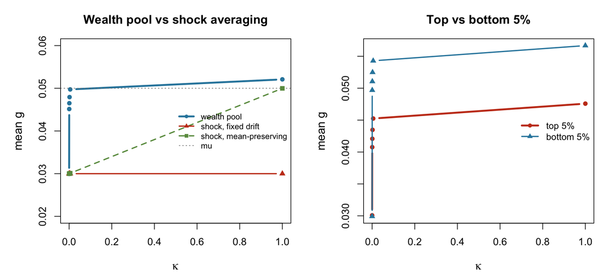

E5：财富池、松弛时间与冲击平均对照

| kappa | 1/kappa | transient | g（全窗） | g（后半窗） | top 5% | bottom 5% | top Δg [95% CI] | 冲击平均 log系综/T |
| --- | --- | --- | --- | --- | --- | --- | --- | --- |
| 0.0000 | — | — | 0.0299 | 0.0300 | 0.0301 | 0.0299 | +0.0000 [+0.0000, +0.0000] | 0.0500 |
| 0.0005 | 2000 | yes | 0.0451 | 0.0451 | 0.0408 | 0.0497 | +0.0107 [+0.0102, +0.0112] | 0.0500 |
| 0.0010 | 1000 | yes | 0.0465 | 0.0462 | 0.0421 | 0.0511 | +0.0120 [+0.0115, +0.0125] | 0.0500 |
| 0.0020 | 500 | yes | 0.0479 | 0.0473 | 0.0435 | 0.0525 | +0.0134 [+0.0129, +0.0139] | 0.0500 |
| 0.0050 | 200 | no | 0.0497 | 0.0487 | 0.0453 | 0.0543 | +0.0152 [+0.0147, +0.0156] | 0.0499 |
| 1.0000 | 1 | — | 0.0521 | 0.0500 | 0.0476 | 0.0567 | +0.0175 [+0.0172, +0.0179] | 0.0300 |

E5：分布端与集中度（补充主表）

| kappa | 累计共担 | g 中位 | g max | g min | 1/Σp² | top 5% 份额 |
| --- | --- | --- | --- | --- | --- | --- |
| 0.0000 | 0.0000 | 0.0300 | 0.0509 | 0.0080 | 2.5 | 0.9989 |
| 0.0005 | 0.3624 | 0.0450 | 0.0559 | 0.0370 | 9.3 | 0.8731 |
| 0.0010 | 0.5936 | 0.0464 | 0.0568 | 0.0385 | 13.2 | 0.8116 |
| 0.0020 | 0.8350 | 0.0478 | 0.0576 | 0.0400 | 20.7 | 0.7265 |
| 0.0050 | 0.9890 | 0.0497 | 0.0587 | 0.0419 | 48.4 | 0.5700 |
| 1.0000 | 1.0000 | 0.0521 | 0.0595 | 0.0448 | 1000.0 | 0.0500 |

财富池把人均 $g$ 从 $\kappa=0$ 的 0.0299 推到 $\kappa=1$ 的 0.0521；$\kappa=0.005$ 时 top 5% 是 0.0453，bottom 5% 是 0.0543，top 的 $\Delta g$ 只有 +0.0152。$\kappa=1$ 的第一期再分配项是 1.9990，之后每期是 0.0499——初始过渡和长期增长必须分开报。补充表还列了三件容易被主表盖住的事：$\kappa=0.005$ 的全体中位数/max/min 分别是 0.0497 / 0.0587 / 0.0419；有效组合规模 $1/\sum p_i^2$ 是 48.4，top 5% 财富份额是 0.5700；评估期累计共担 $1-(1-\kappa)^{900}$ 在 $\kappa=0.0005$ 时只有 0.3624。单 agent 的平均 log-growth 的 SD 是 $\sigma/\sqrt{900}=$ 0.00667，这解释了为什么单个 agent 的 $g$ 看起来几乎不动。全池的精确 log-growth 是 0.050192，小波动近似 $\mu-\sigma^2/(2N)=$ 0.049980；两者分开报，不写成精确等号（精确式里的 correction 是 0.020192）。

**这张图不证明“分享冲击本身不提高时间平均”。** 固定 log-drift 的冲击平均把方差和算术均值一起降了，它的无条件 $E[g]$ 不变是构造出来的；均值保持版反而提高 $g$。Peters 的命题 (Peters 2019) 是“在算术均值不变时降方差会提高时间平均”，不是“任何分享都不提高”。财富池的机制也不同：它改变的是财富权重和池的波动，不是把同一个 $r$ 拆成独立/共同两块。

**主流经济学的对照**是标准期望效用/风险分担：pooling 的收益来自风险厌恶与凸性，而不是时间平均；Peters 团队的贡献是把这件事写成遍历性论证。本文不暗示这个机制是新发现；这里只是复现并划清它与“期望值最大化”的边界。

**把这条边界收成一句。** 本文能主张的是：在指数族/特定的 logit 信息模型里，$T$ 同时扮演熵-产出兑换率与配置弹性；“对谁行的无知程度”只在那个模型里对齐，不是恒等；E5 的共担甚至不经过 $T$。任何把三个对象当成同一个量的读法，都超出了本文的证据。

# 7 边界与未完成的部分

**这份初稿主张的和没主张的：**

- **熵不等于规范意义上的公平。** 熵度量的是”没有人被特殊对待”（程序公平），不是 Rawls 的差别原则，也不是 Sen 的可行能力。一个 Gini 0.5 的最大熵社会，在道德上远谈不上公平。本文给的是**实证基线和权衡的结构**，不是伦理结论。
- **“效率”这里指总产出，不是帕累托效率。** 两者不能混用，映射到经济学论述时必须重新说明。E2 的 dominance 只在 $x\propto\hat a^\beta$ 策略族、有限网格和特定信息模型内成立，不是全局帕累托断言；更不平等但信息更好的配置仍可能产出更高。
- **动能交换模型受主流经济学批评**：货币守恒太强、没有生产、没有异质偏好。它在这里的角色是**机制发生器**，不是经济模型。
- **能力被当成外生的。** 现实中 $a_i$ 有多少是先天、多少是过往资源分配的结果（内生性），这份模型完全没有处理——而这恰恰是公平问题里最要紧的一环。

**本轮已落地（见正文）：**

- **多维能力与匹配**：§4.6 用标量化损失量出”把多维压成一维”的代价；**不声称复现 Ricardo**，也不再用 Sinkhorn 作为必做项。
- **互补性的符号**：§4.5 的 CES 给出 $\beta^\ast(\rho)$；负 $\beta$ 是配置方向反转，不是平等化。
- **遍历性与共担**：§6.1 的财富池；冲击平均只是另一种 treatment，不是干净的负对照。

**仍未完成：**

- **理论待办**：把 $\beta$、$T$、$\sigma_\varepsilon$ 的映射写成可检验模型（不是恒等）；角点解条件的一般化；复制者+变异的 Gibbs 成立条件（§2.3 已给反例与限定）。
- **文献逐条核对原文**：Peters、Kremer、Hansen–Sargent、Chakrabarti、Matějka–McKay 等，付费墙处标”未核全文”。
- **经验校准**：$\rho$、$\sigma_\varepsilon$、$\kappa$ 都还没有行业数据；本文只做机制与量纲。
- **平等作为演化装置，这条线只开了个头。** 反向支配等级、食物分享规范、以及”惩罚搭便车”的实验经济学证据，都还没接进 $T$ 这个框架里量化。要做的是：把群体层面的压制机制写成一个能算的变异率，看它是否落在模型预测的最优温度附近。
- **从指数段跨到幂律段：两账户模型。** 起源篇第 2.7 节把这一问点了出来又交了过来——真实分布的两段由两套动力学统治（加性的工资 / 乘性的资本），而”**我怎么从这一段走到那一段**”它答不了：那里的两段结构是**横截面**分解，说不了谁会移动；而它第 5 章那个模型是**同质**的，人人同一个 $\sigma$，“在尾巴里”纯属当前手气，里面没有任何个体可以做的事。缺的是一条**积累通道**——把工资变成资本的那一步：$K_{t+1}=A_tK_t+sw$，也就是带外生托底的乘性递推（Kesten 那一类）。**注意那个外生项正是起源篇第 5 章刻意拒绝的东西**（它要证”不外加任何东西也能长出幂律尾”），而在这里那个外加项恰恰是问题本身：它就是工资。 要做的是：接点用”加性与乘性对波动的贡献相等”定义（扩散系数 $B_0+br^2$，接点 $\sqrt{B_0/b}$），扫 $(s,\sigma)$，报**平稳跨越概率**与**首次通过时间**的中位数与区间。 **答案的形状可以先预告，而它不舒服**：对数回报期望为负时存在平稳分布，跨过去是可以的、掉回来也是——它是反复发生的事件，不是单向门；期望为正时人人最终跨过去，而那正是起源篇第 5 章证明人口层面开始崩掉的区制。**所以这一问不会有”做 X 就到”形式的答案，只有平稳概率与逗留时间。** **为什么归本篇**：跨越概率是一个**机会**的量，属于公平这一侧，而不是”某机制值多少基尼点”；本篇已经有位次粘性这根轴，对照组 C（持久的储蓄率标签、能力不进入交换）离两账户模型只差一条显式的积累通道；而它要引入的储蓄率与回报波动两个参数没有校准依据——起源篇的立足点是零拟合参数的基线，本篇本来就在跑带 Monte Carlo 区间、并明示”非预先注册”的旋钮实验。它和下面那条”还差一个量，而它需要换一个模型”是同一件事的两半：那里说的”必须先给模型装上工资”，就是这条。
- **公平那一侧的完整展开已拆出**：钉板模型的推导、0.5 的社会后果、非零和的三种增长分法，都在姊妹篇《再论不平等的起源》里。本篇只保留基线。

# 8 一个数不够：基尼之外还要看什么

> **本章是自姊妹篇《再论不平等的起源》整章移入的素材，尚未与本文正文整合。** 下文出现的**「起源篇第 X 节」**一律指那一篇的节号；不带前缀的「第 X 节」指本文自己的节。那一篇的模型是**纯交换**的岛屿模型：总量守恒、没有生产——这正是本文第 3 章用作公平基线的那一台机器。

前面每一章都在问”不平等从哪来、往哪走”。这一章换一个问题：**要说清楚一个社会的不平等，一个数够不够。**

答案已经被前面撞见过三次，只是每次都被就地处理掉了：

- **起源篇第 4.6 节**：两个社会可以有一模一样的基尼，一个是”同一个人的一生摊开”，一个是”一份出生名单”——**基尼分不出它们**。
- **起源篇第 5.5 节**：给定基尼，分布的形状仍然自由——同为 0.5，Pareto 在百倍均值处的概率比指数高约 $10^{40}$ 倍——**基尼定不住形状**。
- **起源篇第 6.2.2 节**：盖茨比曲线的纵轴 $\beta=\rho\cdot\sigma_c/\sigma_p$ 里含着一个离散度之比——**横轴的东西漏进了纵轴**。

这一章把这条线接下去，再走两步：**位置粘性分不出”能翻身”和”被随机重排”**，以及**基尼的排序不蕴含信息量的排序**。

结构是**两根通用轴加一个专用诊断**：基尼与位置粘性只要机制能在同一台交换机器上复算就都能算；而最后那个诊断还需要一个显式的能力变量，只在装了能力的实验里可算——**它不是第三根轴**。

## 8.1 第二根轴：位置粘性

起源篇第 6 章的每一个因素都只报了**一个数**：基尼。但起源篇第 4.5–4.6 节已经论证过，基尼是个截面量——它说不出**同一个人明年还在不在那个位置**。起源篇第 6.2 节量继承时顺手补了一个流动性指标，结果发现基尼和粘性可以各走各的。**那为什么不对起源篇第 6 章的因素都算一遍？**

**但”流动性”这个词底下压着两件不同的事，而它们的价值方向相反。** 这一点不说破，后面全是糊的：

- **代际粘性**：父辈的位置能预测子辈的位置多少。起源篇第 6.2 节那三行继承规则量过——中性继承 1.00、诸子均分 0.68、长子继承 0.18。
- **代内粘性**：**同一个人**在一生之内，隔一段时间之后还在不在原来的位置。

**同一个”粘性”，你想要的方向是相反的。** 在起源篇第 4.6 节写明的那些条件下：

|  | 我们希望它 | 因为 |
| --- | --- | --- |
| **代际**粘性 | **低** | 位置若能由父辈预测，预测力来自财富传递而非本人——穷人的后代该有机会上去，而只靠出身占着高位的该掉下来 |
| **代内**粘性 | **未必要低** | 如果一个人确实更能干，那他持续挣得更多**不是**问题——**问题是位置到底追踪着什么** |

**这个不对称是本章后半段的全部动机。** 代际那一侧，起源篇第 6.2 节已经量完了；这一节量代内那一侧；而”位置到底追踪着什么”——粘性根本回答不了——要留到下一节。

需要一个对代内适用、且对所有机制都能算的指标。代际粘性只有在有”代”的时候才有意义，而起源篇第 6 章大多数机制（能力、储蓄、资本回报、税收、增长）根本不涉及代际。换一个更基本的量：

> **位置粘性** $=$ 相隔 $H$ 轮的两次财富排名之间的**秩相关**（下面取 $H=100$，由 `run2()` 的默认参数给出）。

它问的是”过了这么久，还是原来那批人在上面吗”。$\rho=1$ 是位置完全冻结，$\rho=0$ 是每个人的位置和过去毫无关系。取 $H=100$ 轮：

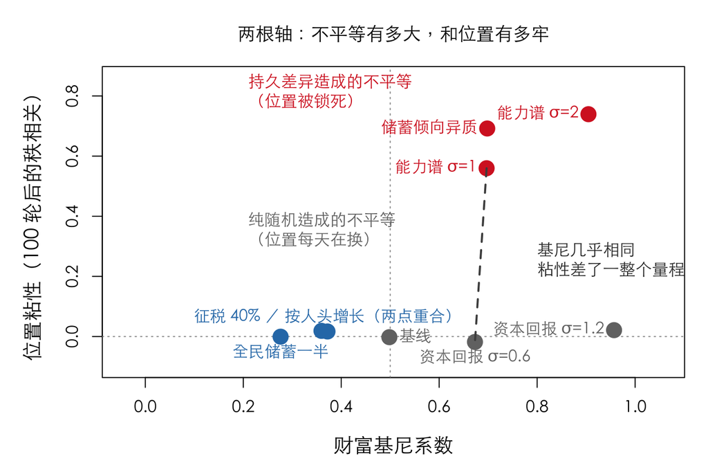

```r
## run1 的扩展版：同一台交换机器，同时吐出基尼和位置粘性
run2 <- function(N = 1500, rounds = 400, mode = "base", p = 0, seed = 1, H = 100){
  set.seed(seed); w <- rep(1, N); half <- N/2
  a <- if (mode == "ability") exp(rnorm(N, 0, p)) else rep(1, N); a <- a/mean(a)
  lam <- switch(mode, save_all = rep(p, N), save_het = runif(N), rep(0, N))
  w0 <- NULL
  for (r in 1:rounds){
    if (r == rounds - H + 1) w0 <- w                              # 记下恰好 H 轮前的位置
    if (mode == "tax" && p > 0){ tx <- p*w; w <- w - tx + sum(tx)/N }
    if (mode == "growflat")     w <- w + p*mean(w)
    if (mode == "capital")      w <- w*exp(-p^2/2 + p*rnorm(N))
    idx <- sample.int(N); i <- idx[1:half]; j <- idx[(half+1):N]
    pooled <- (1-lam[i])*w[i] + (1-lam[j])*w[j]
    e <- if (mode == "ability") rbeta(half, a[i], a[j]) else runif(half)
    w[i] <- lam[i]*w[i] + e*pooled; w[j] <- lam[j]*w[j] + (1-e)*pooled
    if (mode == "capital") w <- w/mean(w)
  }
  c(gini = gini(w), rho = cor(rank(w0), rank(w)))
}
cfg <- data.frame(
  mode = c("base", "save_all", "tax", "growflat", "capital", "capital",
           "save_het", "ability", "ability"),
  p    = c(0, 0.5, 0.4, 1, 0.6, 1.2, 0, 1, 2),
  lab  = c("基线", "全民储蓄一半", "征税 40% ／ 按人头增长（两点重合）", "",
           "资本回报 σ=0.6", "资本回报 σ=1.2", "储蓄倾向异质",
           "能力谱 σ=1", "能力谱 σ=2"), stringsAsFactors = FALSE)
MM <- t(mapply(function(m, p) run2(mode = m, p = p), cfg$mode, cfg$p))   # 不用 M：§5 已占用
cfg$g <- MM[, 1]; cfg$r <- MM[, 2]

ACC <- "#D62728"; BLU <- "#2C7BB6"; GRY <- "gray45"
cfg$col <- ifelse(cfg$r > 0.2, ACC, ifelse(cfg$g < 0.45, BLU, GRY))
par(mar = c(4.8, 5.2, 3.4, 1.2), cex.lab = 1.22, cex.main = 1.12, family = "cjk")
plot(NA, xlim = range(cfg$g) + c(-0.32, 0.10), ylim = range(c(cfg$r, 0)) + c(-0.08, 0.12),
     xlab = "财富基尼系数",
     ylab = "位置粘性（100 轮后的秩相关）", main = "两根轴：不平等有多大，和位置有多牢")
abline(h = 0, lty = 3, col = "gray60"); abline(v = 0.5, lty = 3, col = "gray60")
text(0.19, 0.80, "持久差异造成的不平等\n（位置被锁死）", col = ACC, cex = 1.0, pos = 4)
text(0.19, 0.34, "纯随机造成的不平等\n（位置每天在换）", col = GRY, cex = 1.0, pos = 4)
points(cfg$g, cfg$r, pch = 21, bg = cfg$col, col = cfg$col, cex = 1.9, lwd = 2)
text(cfg$g, cfg$r, cfg$lab, pos = c(4,1,3,1,1,2,2,2,2), cex = 0.98, col = cfg$col)
i1 <- which(cfg$lab == "能力谱 σ=1"); i2 <- which(cfg$lab == "资本回报 σ=0.6")
segments(cfg$g[i1], cfg$r[i1], cfg$g[i2], cfg$r[i2], lty = 2, lwd = 2, col = "gray30")
text(0.78, 0.24, "基尼几乎相同\n粘性差了一整个量程", cex = 1.0, col = "gray20", pos = 4)
```

（这台 `run2()` 就是起源篇第 6.1 节 `run1()` 的扩展版，只多存了一次中途快照。它在基线、储蓄、能力这几档上复现了前面各节的基尼（资本回报那两档的设定与起源篇第 5 章不同——那里带 0.01 漂移、$N$ 与轮数也不同，故只可比不可等同）：基线 0.50、全民储蓄 0.28、能力谱 σ=1 是 0.70、资本回报 σ=0.6 是 0.67——所以两根轴上的数是可比的。）

**这张图上最要紧的是那条虚线连起来的两个点。**

| 机制 | 不平等从哪来 | 基尼系数 | 位置粘性 |
| --- | --- | --- | --- |
| 能力谱 σ = 1 | 人和人之间持久的能力差异 | 0.70 | +0.56 |
| 资本回报 σ = 0.6 | 人人相同的回报率，但回报带涨落 | 0.67 | -0.02 |

**基尼几乎一模一样，位置粘性一个满格、一个是零。** 这就是起源篇第 4.6 节那两个世界，只不过这次不是构造出来的，而是这一章自己的两个机制跑出来的。**用基尼去管理这两个社会，会把它们当成同一件事；但生在其中一个和生在另一个，是完全不同的人生。**

整张图给出一条比单看基尼干净得多的规律：

> **在所测的这几个方案里，位置粘性只出现在带持久个体差异的那一族，与随机性的强弱无关。**（这是对测过的设定与这个时间跨度而言；而且 $\rho\approx0$ 只说明没有单调的秩关联，不等于”毫无关系”。）

三组证据：

- **红色那一族——能力谱、储蓄倾向异质——粘性都在 0.56 以上**（图里按 $\rho>0.2$ 上色）。 它们的共同点是每个人身上挂着一个**不随时间变化的标签**（能力、储蓄率），标签决定了他长期落在哪。基尼越高，标签越显眼。
- **灰色那一族——基线与资本回报——把基尼一路推到 0.96，粘性却始终在零附近。** 涨落是每轮重抽的，没人有持久优势：今天的富人只是最近连着走运的人。**纯随机造成的不平等确实不让位置持久**（代际那一侧见起源篇第 6.2 节，本节量的是一生之内）。

  但这里要把一个顺口的安慰话拆开：**$\rho\approx0$ 有两种完全不同的来源**——位置**可由本人改变**（那是真流动性），或者位置**被随机与制度规则重排**（那只是波动）。**$\rho$ 本身分不出这两者。** 而这个模型里**根本没有能动性变量**，所以它**无法识别**自主流动；观察到的位置变动全部来自它自己施加的随机与制度规则。**因此本章所有”流动性”数字量的都是”位置有没有换人”，不是”能不能翻身”。**
- **蓝色那一族——税收、按人头增长、全民储蓄——把基尼压低，而粘性同样是零。** 它们不锁人。这一点值得单独说：**这些方案降低不平等，并不以牺牲流动性为代价**——图上没有任何一个点同时具备低基尼和高粘性。（**限定**：这里跑的税收是”全员同比例征、按人头返还”这一种；起源篇第 6.3.4 节那些**顶端豁免**的方案没有放进这张图，它们连符号都不同。）

顺带看一眼起源篇第 6.2 节那个结论：**征税 40% 和按人头平分的增长（$g=1$）在两根轴上几乎落在同一个点**（0.37 / +0.02 对 0.36 / +0.02）。

**但要把话说准：它们属于同一族操作，不是这两个参数值恰好等价。** 按均值归一之后，按人头增长 $g$ 给出 $r'=\frac{r+g}{1+g}$，而征税 $\tau$ 给出 $r'=(1-\tau)r+\tau$；配系数得
$$\tau=\frac{g}{1+g}$$
所以 $g=1$ 对应的是 $\tau=0.5$，而不是 0.4。这两点之所以看起来重合，是因为在那一段基尼曲线已经很平——**是数值巧合，不是恒等式**。恒等的是那一族：**凡是给每个人加同一个常数的操作，都是同一个操作，区别只在钱从哪来。**

**一句话把两根轴合起来：** 基尼问”差距有多大”，代内粘性问”这个差距是不是同一批人的”。

**但粘性只说位置牢不牢，说不出它牢在什么上。** 红色那一族里，能力谱和储蓄倾向异质给出的粘性几乎一样高——可一个是”位置追着能力走”，另一个是”位置追着一个跟能力无关的习惯走”。**在这根轴上，这两件事长得一模一样。** 下一节就是为了把它们分开。**推高不平等的机制里，只有一部分同时让位置高度持久；而压低不平等的机制，没有一个是靠固定位置做到的。**

## 8.2 一个专用诊断：财富位次携带多少关于建模能力位次的信息

前一节留下一个它自己答不了的问题：**位置很牢，可它牢在什么上？**

要问这个，模型里必须先有一个”该被追踪的东西”。前一节那些机制里没有——税收、继承、储蓄、通胀都不涉及任何个体禀赋。所以这个诊断**只能在装了能力变量的实验里做**，它**不是第三根轴**，而是一个专用工具。

**这一节用三套安排，回答两个不同的问题：**

|  | 设定 | 用来回答 |
| --- | --- | --- |
| **A** | 窄能力谱 + 强回报噪声 | 与 B 对照：**基尼的排序** 蕴不蕴含信息的排序 |
| **B** | 宽能力谱进入交换 | 两个对照的公共参照 |
| **C** | 储蓄率异质，**能力完全不进入交换** | 与 B 对照：**粘性的排序** 蕴不蕴含信息的排序 |

C 是关键的一臂：它让每个人带一个**持久的、但与能力无关的**标签（储蓄率），于是位置同样很牢——**牢在一个不该被追踪的东西上**。

**度量用互信息**：把财富的秩和能力的秩各切成十分位，量两者之间的互信息 $I\!\left(Q_{10}(R_w);\,Q_{10}(R_a)\right)$，单位 bit。它问的是：**知道一个人在财富上处于第几个十分位，能推断出他在”被建模的能力”上处于第几个十分位多少？**

> **⚠️ 这个”信息”和起源篇第 3.3 节那个”熵”不是同一个量。** 那里的 $H[p]$ 量的是**分布本身有多不确定**（我们对系统知道多少）；这里的 $I$ 量的是**两个位次之间能互相推断多少**。两者都属信息论，但不能互换——**“基线是最大熵解，所以顶端不含信息”这句话是个双关，不成立。**

**设定**：所有臂共用同一台交换机器，每人带一个固定的能力 $a_i=e^{\sigma_a Z_i}$。交换时分成比例
$$e \sim
\mathrm{Beta}\big(\kappa p,\ \kappa(1-p)\big),\qquad
p=\frac{a_i}{a_i+a_j},\qquad \kappa=2\ \text{固定}$$
再叠加一层**额外的**乘性回报噪声 $\sigma_r$。（$\kappa$、夹紧边界、$N$、轮数、分箱数、置换次数的取值都在下一段用 inline 报出，不留在代码里。）

**$\kappa$ 为什么必须固定**：起源篇第 6.1 节（以及第 8.1 节那张两根轴图里的能力谱两点）用的写法是 `Beta(a_i, a_j)`，它的方差是 $p(1-p)/(a_i+a_j+1)$——**拧宽能力谱会同时改掉交换噪声**，两个效应混在一起。固定 $\kappa$ 让总浓度不变（$\kappa=2$ 在 $p=1/2$ 时正好退回均匀分布，与起源篇基线一致）。**但也别说过头**：$\operatorname{Var}(e\mid p)=p(1-p)/(\kappa+1)$ 仍随 $p$ 变化，固定的只是总浓度。

**三种随机性要分开叫**：**交换随机性**（Beta 抽样，$\sigma_r=0$ 时依然存在，所以那不是”无噪声”）、**乘性回报噪声**（$\sigma_r$）、**估计量零分布**（下面的置换）。

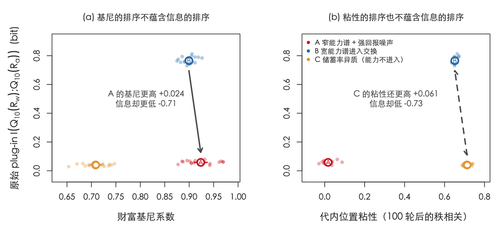

```r
mi_from_dec <- function(dx, dy, D){
  pj <- table(factor(dx, 1:D), factor(dy, 1:D))/length(dx); s <- pj > 0
  sum(pj[s]*log2(pj[s]/outer(rowSums(pj), colSums(pj))[s]))
}
dec <- function(x, D) ceiling(rank(x, ties.method = "first")/length(x)*D)

## mode = "ability"：能力进入交换的分成；mode = "save"：改由与能力无关的储蓄率驱动位置
sortdx <- function(mode = "ability", sa = 2, sr = 0, N = 1500, rounds = 400, kappa = 2,
                   D = 10, H = 100, eps = 1e-12, seed = 1, nperm = 999){
  set.seed(seed)
  a   <- exp(sa*rnorm(N))                                  # 能力：三臂都有，也都是想追踪的那个量
  lam <- if (mode == "save") runif(N) else rep(0, N)        # 储蓄率：持久，但与能力无关
  w <- rep(1, N); half <- N/2; w0 <- NULL; clamped <- 0
  for (r in 1:rounds){
    if (r == rounds - H + 1) w0 <- w                        # 记下恰好 H 轮前的位置
    if (sr > 0) w <- w*exp(-sr^2/2 + sr*rnorm(N))           # 额外的乘性回报噪声（保均值）
    idx <- sample.int(N); i <- idx[1:half]; j <- idx[(half+1):N]
    pooled <- (1-lam[i])*w[i] + (1-lam[j])*w[j]
    e <- if (mode == "ability"){
           p  <- a[i]/(a[i] + a[j])
           e0 <- rbeta(half, kappa*p, kappa*(1-p))
           clamped <- clamped + sum(e0 < eps | e0 > 1-eps)  # 真正被夹紧改变的
           pmin(pmax(e0, eps), 1-eps)
         } else runif(half)                                 # 能力完全不进入分成
    w[i] <- lam[i]*w[i] + e*pooled; w[j] <- lam[j]*w[j] + (1-e)*pooled
    if (sr > 0) w <- w/mean(w)                              # 仅防溢出；秩/基尼/MI 皆尺度不变
  }
  stopifnot(!any(duplicated(w)), !any(duplicated(a)), all(is.finite(w)), all(w > 0))
  dw <- dec(w, D); da <- dec(a, D); mi <- mi_from_dec(dw, da, D)
  if (nperm > 0){
    nl <- replicate(nperm, mi_from_dec(dw, sample(da), D))  # 种子内置换，保留两边边缘分布
    per <- c(nmean = mean(nl), nlo = unname(quantile(nl, .025)), nhi = unname(quantile(nl, .975)),
             pperm = (1 + sum(nl >= mi))/(nperm + 1))       # +1 规则：p 永远 > 0
  } else per <- c(nmean = NA, nlo = NA, nhi = NA, pperm = NA)
  c(gini = gini(w), stick = cor(rank(w0), rank(w)), mi = mi, per,
    occ = sum(table(dw, da) > 0), zero = sum(w <= 0), clamp = clamped/(rounds*half))
}
SD_N <- 1500; SD_R <- 400; SD_D <- 10; SD_H <- 100; SD_P <- 999
SD_SEEDS_A <- 101:120; SD_SEEDS_B <- 201:220; SD_SEEDS_C <- 301:320   # 三块互不相交
go <- function(seeds, ...) t(sapply(seeds, function(s)
        sortdx(..., N=SD_N, rounds=SD_R, D=SD_D, H=SD_H, seed=s, nperm=SD_P)))
SD_A <- go(SD_SEEDS_A, mode="ability", sa=0.25, sr=1.2)   # 窄能力谱 + 强回报噪声
SD_B <- go(SD_SEEDS_B, mode="ability", sa=2.00, sr=0.0)   # 宽能力谱进入交换
SD_C <- go(SD_SEEDS_C, mode="save",    sa=2.00, sr=0.0)   # 储蓄率异质，能力不进入交换
welch <- function(x, y){
  n1 <- length(x); n2 <- length(y); v1 <- var(x)/n1; v2 <- var(y)/n2
  df <- (v1+v2)^2/(v1^2/(n1-1) + v2^2/(n2-1)); d <- mean(x) - mean(y)
  h  <- qt(.975, df)*sqrt(v1+v2); c(d = d, lo = d-h, hi = d+h, df = df)
}
## 对照一：基尼的排序 vs 信息的排序（A 对 B）
W_AB_g <- welch(SD_A[,"gini"], SD_B[,"gini"]); W_AB_i <- welch(SD_A[,"mi"], SD_B[,"mi"])
## 对照二：粘性的排序 vs 信息的排序（C 对 B）
W_CB_s <- welch(SD_C[,"stick"], SD_B[,"stick"]); W_CB_i <- welch(SD_C[,"mi"], SD_B[,"mi"])
SD_PBAD <- mean(SD_A[, "pperm"] > 0.05)

## 稳健性：只查符号，不查数值稳定（分箱数、人口规模、夹紧常数各扫一遍；用第四块种子）
SD_SENS <- do.call(rbind, lapply(list(
    list(lab = "基准 D=10, N=1500",        D = 10, N = 1500, eps = 1e-12),
    list(lab = "分箱 D=5",                 D =  5, N = 1500, eps = 1e-12),
    list(lab = "分箱 D=20（N 同时提到 3000）", D = 20, N = 3000, eps = 1e-12),
    list(lab = "人口 N=3000",              D = 10, N = 3000, eps = 1e-12),
    list(lab = "夹紧 eps=1e-6",            D = 10, N = 1500, eps = 1e-6)),
  function(cf){
    f <- function(sa, sr) rowMeans(sapply(401:404, function(s)
           sortdx("ability", sa, sr, N = cf$N, rounds = SD_R, D = cf$D,
                  eps = cf$eps, seed = s, nperm = 0)[c("mi", "gini")]))
    a <- f(0.25, 1.2); b <- f(2, 0)
    data.frame(设定 = cf$lab, A = a["mi"], B = b["mi"],
               dMI = a["mi"] - b["mi"], dG = a["gini"] - b["gini"])
  }))

UP <- "#D62728"; DN <- "#2C7BB6"; GN <- "#E8A33D"
ARMS <- list(list(SD_A, UP, "A"), list(SD_B, DN, "B"), list(SD_C, GN, "C"))
ci_m <- function(v){ n <- length(v); qt(.975, n-1)*sd(v)/sqrt(n) }
par(mfrow = c(1, 2), mar = c(4.8, 5.2, 3.4, 1.0), cex.lab = 1.15, cex.main = 1.04, family = "cjk")
yr <- range(c(SD_A[,"mi"], SD_B[,"mi"], SD_C[,"mi"], 0)) + c(-0.04, 0.10)

## (a) 基尼 vs 信息：A 与 B 的排序相反
xr <- range(c(SD_A[,"gini"], SD_B[,"gini"], SD_C[,"gini"])) + c(-0.02, 0.02)
plot(NA, xlim = xr, ylim = yr, xlab = "财富基尼系数",
     ylab = expression(paste("原始 plug-in ", I(Q[10](R[w]) * ";" * Q[10](R[a])), "  (bit)")),
     main = "(a) 基尼的排序不蕴含信息的排序")
for (M in ARMS){ d <- M[[1]]; cl <- M[[2]]
  points(d[,"gini"], d[,"mi"], pch = 16, col = adjustcolor(cl, .35), cex = 0.95)
  gx <- mean(d[,"gini"]); my <- mean(d[,"mi"])
  segments(gx-ci_m(d[,"gini"]), my, gx+ci_m(d[,"gini"]), my, col = cl, lwd = 2.4)
  segments(gx, my-ci_m(d[,"mi"]), gx, my+ci_m(d[,"mi"]), col = cl, lwd = 2.4)
  points(gx, my, pch = 21, bg = "white", col = cl, lwd = 3, cex = 1.9)
  text(gx, my, M[[3]], col = cl, font = 2, cex = 0.9) }
arrows(mean(SD_B[,"gini"]), mean(SD_B[,"mi"])-0.07, mean(SD_A[,"gini"]), mean(SD_A[,"mi"])+0.07,
       length = 0.09, lwd = 2.6, col = "gray35")
text(mean(xr), mean(yr)*1.15, sprintf("A 的基尼更高 %+.3f\n信息却更低 %+.2f",
     W_AB_g["d"], W_AB_i["d"]), col = "gray20", cex = 0.98)

## (b) 粘性 vs 信息：B 与 C 的粘性几乎一样，信息差一个数量级
xs <- range(c(SD_A[,"stick"], SD_B[,"stick"], SD_C[,"stick"])) + c(-0.05, 0.05)
plot(NA, xlim = xs, ylim = yr, xlab = "代内位置粘性（100 轮后的秩相关）",
     ylab = "", main = "(b) 粘性的排序也不蕴含信息的排序")
for (M in ARMS){ d <- M[[1]]; cl <- M[[2]]
  points(d[,"stick"], d[,"mi"], pch = 16, col = adjustcolor(cl, .35), cex = 0.95)
  gx <- mean(d[,"stick"]); my <- mean(d[,"mi"])
  segments(gx-ci_m(d[,"stick"]), my, gx+ci_m(d[,"stick"]), my, col = cl, lwd = 2.4)
  segments(gx, my-ci_m(d[,"mi"]), gx, my+ci_m(d[,"mi"]), col = cl, lwd = 2.4)
  points(gx, my, pch = 21, bg = "white", col = cl, lwd = 3, cex = 1.9)
  text(gx, my, M[[3]], col = cl, font = 2, cex = 0.9) }
arrows(mean(SD_C[,"stick"]), mean(SD_C[,"mi"])+0.07, mean(SD_B[,"stick"]), mean(SD_B[,"mi"])-0.07,
       length = 0.09, lwd = 2.6, col = "gray35", code = 3, lty = 2)
text(mean(xs), mean(yr)*1.15, sprintf("C 的粘性还更高 %+.3f\n信息却低 %+.2f",
     W_CB_s["d"], W_CB_i["d"]), col = "gray20", cex = 0.98)
legend("topleft", c("A 窄能力谱 + 强回报噪声", "B 宽能力谱进入交换",
                       "C 储蓄率异质（能力不进入）"),
       pch = 16, col = c(UP, DN, GN), bty = "n", cex = 0.85)
```

**这一节的全部参数都写在这里，不藏在代码里**：人口 1500 人、跑 400 轮、粘性的时间跨度 100 轮、财富与能力各切 10 个十分位、每个种子内做 999 次置换、**三臂各 20 个种子且用互不相交的三块**（101–120 / 201–220 / 301–320）——同一个 seed 下各臂会共用同一批高斯抽样，**那是配对不是独立**，而下面用的是独立组 Welch 推断。交易分成 $e$ 被**夹紧**在 $[10^{-12},\,1-10^{-12}]$，防 `rbeta` 在极端参数下返回恰好 0 或 1；生效频率下面单独交代。

| 设定 | 财富基尼 | 代内粘性 | 原始 $I(Q_{10}(R_w);Q_{10}(R_a))$（bit） | 置换零分布 | 置换 p | 夹紧生效 |
| --- | --- | --- | --- | --- | --- | --- |
| A：窄能力谱 + 强回报噪声 | 0.924 | 0.017 | 0.058 | 0.040，95% 带 [0.028, 0.053] | 0.070 | 0.0% |
| B：宽能力谱进入交换 | 0.899 | 0.651 | 0.766 | 0.039，95% 带 [0.028, 0.053] | 0.001 | 14.1% |
| C：储蓄率异质，能力不进入交换 | 0.709 | 0.712 | 0.040 | 0.040，95% 带 [0.028, 0.053] | 0.458 | 0.0% |

**对照一（A 对 B）：基尼的排序不蕴含信息的排序。**

- 财富基尼之差 +0.0242，95% Monte Carlo 区间 [+0.0097, +0.0386]
- 信息量之差 -0.7072，区间 [-0.7184, -0.6960]

**对照二（C 对 B）：粘性的排序同样不蕴含信息的排序——而这一条更要紧。**

- 代内粘性之差 +0.0612，区间 [+0.0519, +0.0704]——**C 的位置比 B 还牢**
- 信息量之差 -0.7253，区间 [-0.7360, -0.7146]——**而 C 的置换 $p$ 是 0.46，完全落在零分布里**

> **C 的位置牢得很，牢在一个跟能力毫无关系的东西上。** 它的每个人带着一个终身不变的储蓄率，位置于是高度持久；但那个持久的标签不是能力，所以财富位次对能力位次一无所知。**粘性告诉你位置牢不牢，说不出它牢在什么上。**

两条对照合起来，本章的递进就完整了：

| 用一个数 | 它分不出 | 谁能分出 |
| --- | --- | --- |
| **基尼** | 同一个基尼，位置可以每天在换，也可以一辈子不动 | 位置粘性（第 8.1 节） |
| **位置粘性** | 同样牢的位置，可以牢在能力上，也可以牢在与能力无关的标签上 | 这一节的排序诊断 |
| **排序诊断** | 见下一小节——它也有自己的盲区 | 起源篇没有 |

**三条限定仍然缺一不可：** 这些区间是 **Monte Carlo 区间**，不是对现实社会的统计显著性；这三组参数**不是预先注册的预测**（它们在探索之后才锁定，随后换另外记录的种子块重跑，只能证明结论不依赖最初那批种子）；而 $\sigma_a$、$\sigma_r$、储蓄率异质都是**被拧的旋钮**，基尼、粘性、信息量是三个**并列的结果**——**不存在稳定的两两关系**，更不能说”不平等销毁了信息”。

**A 臂弱到什么程度，要用种子内的比较来说。** 它的观测值紧贴自身置换零分布：$p$ 均值 0.070，最差种子 0.60，**20% 的种子在 0.05 的水平上拒不掉零假设**。所以准确的说法是”**关联只勉强高出自身底噪**”，不是”完全没有信息”。C 臂则连勉强都谈不上（$p=$ 0.46）。

**夹紧那个常数在 B 臂真的生效。** A 与 C 从未触发（0.0% / 0.0%），B 臂有 14.1% 的抽样被夹——宽能力谱下 $p$ 会小到 $10^{-6}$ 量级，`rbeta` 几乎必然返回端点。这是一个**全局比率**，它并不直接证明”底部十分位由常数决定”；更直接的检验是把常数本身横扫一遍，见下。

| 设定 | A 的 MI | B 的 MI | 信息差（A−B） | 基尼差（A−B） |
| --- | --- | --- | --- | --- |
| 基准 D=10, N=1500 | 0.051 | 0.757 | -0.706 | +0.050 |
| 分箱 D=5 | 0.020 | 0.604 | -0.585 | +0.050 |
| 分箱 D=20（N 同时提到 3000） | 0.103 | 0.870 | -0.767 | +0.046 |
| 人口 N=3000 | 0.032 | 0.748 | -0.716 | +0.046 |
| 夹紧 eps=1e-6 | 0.051 | 0.771 | -0.721 | +0.050 |

**信息**那一侧的差在 -0.58 到 -0.77 之间，**符号从未改变**。

**两条方法上的话必须写下来：** 原始 MI 之差是**估计量之差**，不是被估量之差——零分布相同不蕴含两个备择下的 plug-in 偏差相同，稳健性靠的是上面那张扫描表，不是”偏差互相抵消”；占用格数（A 100、B 88、C 100，共 100 格，每格期望 15）报出来是为了让读者判断稀不稀疏。

### 8.2.1 这把尺自己的盲区：能力不是给定的

前面每一步都默认了一件事——**能力是外生的**：每个人在第 0 轮抽到一个 $a_i$，此后终身不变。现实显然不是这样。**一个人能力强却一直没机会施展，能力会退化；一个人本来平平，被运气推到一个锻炼人的位置上，能力会长出来。** 位置不只反映能力，**位置也塑造能力**。

这条通道在上面的模型里**根本不存在**——不是没测出来，是构造上就没有。那么把它加进去会怎样？让位置每轮反过来推一把能力（位次靠前的往上、靠后的往下，强度 $\eta$），在一个**运气占上风**的设定里（窄能力谱 + 强回报噪声，也就是 A 臂那种世界）跑一遍：

```r
endo <- function(eta, sa = 0.25, sr = 1.2, N = 1200, rounds = 400, kappa = 2,
                 D = 10, seed = 1, nperm = 299){
  set.seed(seed); a0 <- exp(sa*rnorm(N)); a <- a0; w <- rep(1, N); half <- N/2
  for (r in 1:rounds){
    w <- w*exp(-sr^2/2 + sr*rnorm(N))
    idx <- sample.int(N); i <- idx[1:half]; j <- idx[(half+1):N]
    p <- a[i]/(a[i] + a[j])
    e <- pmin(pmax(rbeta(half, kappa*p, kappa*(1-p)), 1e-12), 1 - 1e-12)
    pool <- w[i] + w[j]; w[i] <- e*pool; w[j] <- (1-e)*pool
    w <- w/mean(w)
    if (eta > 0) a <- a*exp(eta*(rank(w)/N - 0.5))     # 位置 -> 能力：位次靠前的能力上升
  }
  dw <- dec(w, D)
  c(gini = gini(w),
    mi_now   = mi_from_dec(dw, dec(a,  D), D),         # 位置 vs 此刻的能力
    mi_endow = mi_from_dec(dw, dec(a0, D), D),         # 位置 vs 最初的禀赋
    acor     = cor(rank(a0), rank(a)))                 # 能力的排序被改写了多少
}
ETA <- c(0, 0.02, 0.05, 0.1, 0.2)
ENDO <- t(sapply(ETA, function(x) rowMeans(sapply(501:506, function(s) endo(x, seed = s)))))
```

| 反馈强度 η | 财富基尼 | MI(位置, 此刻的能力) | MI(位置, 最初的禀赋) | 能力秩序还剩多少 |
| --- | --- | --- | --- | --- |
| 0（上面用的模型） | 0.932 | 0.063 | 0.063 | 1.000 |
| 0.02 | 0.942 | 0.251 | 0.211 | 0.902 |
| 0.05 | 0.993 | 0.844 | 0.427 | 0.790 |
| 0.10 | 0.998 | 0.883 | 0.315 | 0.698 |
| 0.20 | 0.998 | 0.728 | 0.190 | 0.589 |

**读第三列和第四列的差。** 没有反馈时两者相同（能力就是禀赋）。反馈一开，**用”此刻的能力”去量，这个系统看起来越来越像一个择优体系**——$I$ 从 0.063 涨到 0.883；**而用”最初的禀赋”去量，位置对天赋携带的信息始终低得多**（$\eta=0.1$ 时只有 0.315）。与此同时能力的排序被大幅改写（秩相关掉到 0.589）。

> **一个由运气发牌、再把能力塑造成与牌面相符的系统，在”当下能力”这把尺上会显示为高度择优。** 而它实际上只是**把运气写成了能力**。

**所以这把尺的判据要加一层限定，而且这一层是硬的：**

> **$I$ 高只在能力外生时才意味着”位置在追踪能力”。** 一旦位置能反过来塑造能力，同一个高 $I$ 也可以意味着”**系统制造了它随后奖励的那种能力**”——**而 $I$ 分不出这两者。**

**用起源篇第 4.6.2 节那条效率的读法看，这一层格外要命。** 那里说：能力之所以要紧，是因为它携带”资源放这里会产出更多”的信息。**但如果那份能力是被位置事后造出来的，这条信息就不是配置的依据，而是配置的产物**——系统不是找到了该给的人，是把拿到资源的人变成了”该给的人”。**从效率的角度，这两件事完全不同**：前者是把资源送到已有的产能上，后者只是让先到的位置自我加冕。

这正好是本章那条递进的第四环，而且它落在自己身上：**基尼分不出两个世界 → 粘性分不出牢在什么上 → 信息量分不出”追踪”与”制造”。** 每一环都是同一个毛病——**一维的量压掉了要紧的那一维**——只不过这一次，被压掉的那一维是因果方向。

要区分”追踪”与”制造”，需要的不是更好的指标，是**能力如何形成的模型**：$\eta$ 在现实中有多大、它作用在谁身上、多久见效。起源篇没有，列在那一篇的末节。

**最后回到价值层。** 这把尺**既不量福利，也不量效率**：秩上排得再准，配置的量级也可以差得一塌糊涂；真实的生产性配置还依赖多维匹配，一维的秩互信息看不到。加上刚才那一层，它连”追踪能力”这件事本身都只在能力外生时才成立。**在什么生产假设下，某些能力—资源匹配会提高产出**——那需要一个能直接算产出的生产模型。起源篇没有，**而那正是本文前六章在做的事**（第 4 章把能力接进效率一侧，第 5 章量不确定性把最优集中度推低多少）。这一章只把这几把尺摆出来，并说明每一把量不到什么；**把它们接到产出上去，是整合这份素材时要做的第一件事。**

## 8.3 还差一个量，而它需要换一个模型

两根轴和那个诊断之外，起源篇第 4.6 节其实还点过一个量：**收入的永久／暂时成分分解**（Gottschalk–Moffitt）。它把一个人的收入波动拆成两块——**永久成分**（这个人本来就在什么位置）和**暂时成分**（他这一年的起落）。在那五个流动性指标里，它是唯一一个能直接回答”**一生之内位置会不会换人、换的是随机起落还是持久位置**”的，因为它区分的正是”同一个人的起落”与”不同人的固定位置”。

起源篇没有做它，而且**不是因为麻烦，是因为这个模型没有资格做**。理由起源篇第 4.4 节已经量过：**岛上没有生产。** 现实中绝大部分收入是**工资**，是被生产出来的；而岛上的”收入”只是别人转过来的金币。这带来一个致命的后果——**这个模型里的收入基尼是核算窗口的函数**（1 轮 0.55，100 轮 0.06，1000 轮 0.02），它压根没有一个稳定的”年收入”可言。而永久／暂时分解要求的第一件事，就是有一个**时间尺度确定的年收入**，才谈得上把它拆成两块。

所以补这一块不是加一段代码，是**换一个模型**：得给岛民装上工资——每轮凭劳动获得一份新的产出。而那一步会立刻打破**总量守恒**，也就是把模型推进起源篇第 6.2 节”增长”那一族里去。**换句话说，这个缺口不在起源篇的边界之内，而在边界之外一步。**

这本身也是个值得记住的结论：**纯交换模型能说清楚存量怎么分布，说不清楚流量怎么波动。** 本章所有关于”流动性”的话，都是关于**财富位次**的，不是关于收入的。

# 附录：几条闭式与推导

本附录把正文用到的几条标准结果补成可检查的推导。它们不是新结果，目的是让正文的每个“所以”都有落点；公式里的常数和闭式不属于需要 FREG 登记的实测值。

## A.1 Theil $=\ln N-H$

Theil 指数以 $N$ 个等概率状态为参照：

$$T_{\text{Theil}}=\sum_i
p_i\ln\frac{p_i}{1/N}
=\sum_i p_i\ln p_i+\ln N=\ln N-H[p].$$

数值核验直接对任意离散分布比较两边；`stopifnot` 在机器精度内通过（见下方 chunk）。

## A.2 四个 Gini 闭式

- 指数 $\mathrm{Exp}(\mu)$：$G=1/2$，与 $\mu$ 无关。
- Gamma$(k)$：$G=\Gamma(k+\tfrac12)/[\sqrt{\pi}\,\Gamma(k+1)]$。
- 对数正态$(\sigma)$：$G=2\Phi(\sigma/\sqrt2)-1$。
- Pareto$(\alpha)$（$\alpha>1$）：$G=1/(2\alpha-1)$。

这四条都只用分位函数做确定性数值核验：取 $u_i=(i-\tfrac12)/n$，$x_i=Q(u_i)$，再与闭式比较；不靠一次随机样本。

```r
## Theil = ln N - H
set.seed(1)
N <- 1000
p <- rexp(N); p <- p/sum(p)
T_theil <- sum(p*log(p*N)); H <- -sum(p*log(p))
stopifnot(abs(T_theil - (log(N) - H)) < 1e-12)

## Gini closed forms, deterministic quantile grid
gq <- function(qfun, n = 2e5) gini(qfun((seq_len(n) - 0.5)/n))
g_exp <- gq(function(u) qexp(u, rate = 1))
g_gam <- gq(function(u) qgamma(u, shape = 4, rate = 1))
g_ln  <- gq(function(u) qlnorm(u, meanlog = 0, sdlog = 0.8))
g_par <- gq(function(u) (1 - u)^(-1/2.5))          # Pareto(xmin=1, alpha=2.5)
stopifnot(
  abs(g_exp - 0.5) < 1e-3,
  abs(g_gam - gamma(4.5)/(sqrt(pi)*gamma(5))) < 1e-3,
  abs(g_ln  - (2*pnorm(0.8/sqrt(2)) - 1)) < 1e-3,
  abs(g_par - 1/(2*2.5 - 1)) < 1e-3)
```

## A.3 $x_i\propto a_i^{1/(1-\gamma)}$ 与角点

对 $\max\sum_i a_i x_i^\gamma$，约束 $\sum_i x_i=R$，拉格朗日函数为

$$\mathcal L=\sum_i a_i
x_i^\gamma-\lambda\Big(\sum_i x_i-R\Big).$$

内点一阶条件 $\gamma a_i x_i^{\gamma-1}=\lambda$，于是

$$x_i\propto
a_i^{1/(1-\gamma)}.$$

角点条件：$0<\gamma<1$ 时 $x^\gamma$ 凹，内点解是全局最大；$\gamma=1$ 时目标线性，最大在角点——把全部资源给 $a_i$ 最大者（只有所有 $a_i$ 相等时，内部任意分才同产出）；$\gamma>1$ 时 $x^\gamma$ 凸，最大值同样在角点。正文的“赢家通吃”指后两种的角点，不是第一种的内点。

## A.4 $\max\sum_i a_i x_i+T H$ 的归一化与量纲

取 $H=-\sum_i x_i\ln x_i$，约束 $\sum_i x_i=R$：

$$\mathcal L=\sum_i a_i x_i-T\sum_i x_i\ln
x_i-\lambda\Big(\sum_i x_i-R\Big).$$

对 $x_i$ 求一阶条件：

$$a_i-T(\ln x_i+1)-\lambda=0
\quad\Longrightarrow\quad
x_i=\exp\!\left(\frac{a_i-\lambda-T}{T}\right).$$

归一化 $\sum_i x_i=R$ 给出

$$x_i=R\,\frac{e^{a_i/T}}{\sum_j
e^{a_j/T}}.$$

量纲：$a_i/T$ 必须无量纲，所以 $T$ 与 $a_i$ 同单位；$T$ 是“一单位产出换一 nat 熵”的影子价格。$T\to0$ 时质量集中到 $a_i$ 最大者（角点），$T\to\infty$ 时趋于均匀。这个 $T$ 是**熵罚权重**；它是否等于观测不确定性 $\sigma_\varepsilon$ 的某个函数，取决于具体信息模型，不是恒等。

## A.5 Kelly 的增长率损失 $=$ KL

结果 $i$ 的概率为 $p_i$，把财富比例 $x_i$（$\sum_i x_i=1$）押在结果 $i$ 上，期望对数增长为

$$g(x)=\sum_i p_i\ln x_i.$$

在 $\sum_i x_i=1$ 下最大化，拉格朗日一阶条件给 $x_i=p_i$。最优值 $g(p)=\sum_i p_i\ln p_i$，所以

$$g(p)-g(x)=\sum_i
p_i\ln\frac{p_i}{x_i}=D_{\mathrm{KL}}(p\|x)\ge0.$$

偏离 Kelly 的增长率损失正好是 KL；这里没有 $T$，也不经过不确定性论证。

## A.6 Becker 超模/次模与配对方向

设类型 $a$ 与类型 $x$ 匹配的 payoff 为 $u(a,x)$。若

$$\frac{\partial^2 u}{\partial a\,\partial
x}\ge0
\quad\text{（increasing differences / supermodular）},$$

则正排序匹配（高配高、低配低）使总支付最大；若 $\le0$（submodular），则负排序匹配。可转移效用下这是充分条件；不可转移效用（Legros–Newman）还需要额外的可行性/稳定性条件。本文只用“方向”这一层，不把 Becker 的匹配定理当成配置集中度的定理：E4 问的是“给多少”，不是“配给谁”。

## A.7 E4/E3/E5 数值自检

这里把正文没展开的尾项补成可执行的检查；不改变主结果。

```r
## E4: rho=0, grid edge, grid vs analytic
stopifnot(abs(E4_tab$beta[E4_tab$rho == 0]) < 1e-12,
          abs(E4_tab$beta_an[E4_tab$rho == 0]) < 1e-12,
          all(E4_tab$beta > min(E4_betas)),
          all(E4_tab$beta < max(E4_betas)),
          max(abs(E4_tab$beta - E4_tab$beta_an)) < 0.05,
          E4_leon["conv"] == 100)

## E4: Leontief A/B/C — rho -> -inf, distance to x propto 1/a shrinks
e4_close <- function(rho){
  b <- rho / (1 - rho)
  x <- E4_R * E4_a^b / sum(E4_a^b)
  tgt <- E4_R * (1 / E4_a) / sum(1 / E4_a)
  c(maxdiff = max(abs(x - tgt)),
    mingap = (min(E4_a * x) - min(E4_a * tgt)) / min(E4_a * tgt),
    minout = min(E4_a * x))
}
e4_lev <- t(vapply(c(-10, -20, -50), e4_close, numeric(3)))
stopifnot(all(diff(e4_lev[, "maxdiff"]) < 0),
          all(diff(abs(e4_lev[, "mingap"])) < 0),
          all(diff(e4_lev[, "minout"]) > 0))

## E3: Hungarian exhaustive check, ties, maximization, primal feasibility
perms <- function(v){
  if (length(v) == 1L) return(list(v))
  unlist(lapply(seq_along(v), function(i)
    lapply(perms(v[-i]), function(p) c(v[i], p))), recursive = FALSE)
}
set.seed(42)
for (s in 1:3){
  cost <- matrix(sample(1:3, 49, replace = TRUE), 7, 7)
  ass <- hungarian(cost)
  stopifnot(sort(ass) == 1:7)
  brute <- min(vapply(perms(1:7), function(p) sum(cost[cbind(1:7, p)]), numeric(1)))
  stopifnot(abs(sum(cost[cbind(1:7, ass)]) - brute) < 1e-9)
  ass2 <- hungarian(-cost)
  brute2 <- max(vapply(perms(1:7), function(p) sum(cost[cbind(1:7, p)]), numeric(1)))
  stopifnot(abs(sum(cost[cbind(1:7, ass2)]) - brute2) < 1e-9)
}

## E5: single-agent SD and world-level CI sanity
e5_ci_cols <- setdiff(colnames(E5_ci), c("g_first", "g_rest"))
stopifnot(abs(E5_sigma / sqrt(E5_T) - 0.2 / 30) < 1e-12,
          nrow(E5_arr) == E5_W,
          all(is.finite(E5_ci[, e5_ci_cols])),
          abs(E5_L_exact - E5_L_approx) < 1e-3)
```

E4 的 Leontief A/B/C 用 $\rho=-10,-20,-50$ 的连续 CES 解与 $x\propto1/a$ 比较；预算约束的 LP 由正文的原始-对偶证书覆盖（$x,y,z$ 同时可行且 primal=dual），不另写 simplex。E3 的 Hungarian 用 $N=7$ 穷举全排列（含并列值）验证最优值与最大化转换；原始可行性直接检查 assignment 是排列。对偶可行性没有暴露势变量，故以穷举最优性替代并在此明写。

# 参考文献

Boehm, Christopher. 1999. *Hierarchy in the Forest: The Evolution of Egalitarian Behavior*. Harvard University Press.

Chakraborti, Anirban, and Bikas K. Chakrabarti. 2000. “Statistical Mechanics of Money: How Saving Propensity Affects Its Distribution.” *The European Physical Journal B* 17 (1): 167–70. https://doi.org/10.1007/s100510070173.

Chatterjee, Arnab, Bikas K. Chakrabarti, and S. S. Manna. 2004. “Pareto Law in a Kinetic Model of Market with Random Saving Propensity.” *Physica A: Statistical Mechanics and Its Applications* 335 (1-2): 155–63. https://doi.org/10.1016/j.physa.2003.11.014.

Drăgulescu, Adrian, and Victor M. Yakovenko. 2000. “Statistical Mechanics of Money.” *The European Physical Journal B* 17 (4): 723–29. https://doi.org/10.1007/s100510070114.

Matějka, Filip, and Alisdair McKay. 2015. “Rational Inattention to Discrete Choices: A New Foundation for the Multinomial Logit Model.” *American Economic Review* 105 (1): 272–98.

Peters, Ole. 2019. “The Ergodicity Problem in Economics.” *Nature Physics* 15 (12): 1216–21. https://doi.org/10.1038/s41567-019-0732-0.

Sims, Christopher A. 2003. “Implications of Rational Inattention.” *Journal of Monetary Economics* 50 (3): 665–90.

Yakovenko, Victor M., and J. Barkley Rosser. 2009. “Colloquium: Statistical Mechanics of Money, Wealth, and Income.” *Reviews of Modern Physics* 81 (4): 1703–25. https://doi.org/10.1103/RevModPhys.81.1703.